# R Replication Assignment

Max Dippel

11/16/2021

## Description of Assignment

Today, I will be discussing my attempts to replicate “The role of nocturnal omnivorous lemurs as seed dispersers in Malagasy rain forests” by Ramananjato et al. published in biotropica in 2020. First though, I would like to mention that I had meant to discuss another study with you all today. This paper, “Crop Feeding by Brown Howlers (*Alouatta guariba clamitans*) in Forest Fragments: The Conservation Value of Cultivated Species” by Oscar Chaves and Julio Cesar Bicca-Marques, proved difficult to replicate for a variety of reasons. The study was the analysis of the fruits howler monkeys ate of different species in three different orchards. However, the data set did not include the basal area of each species within each orchard making it impossible to calculate the fruit availability index of each species. Secondly, a link in the study to the market value of each fruit species was no longer operational. This made it impossible to calculate the economic value of the fruit which was lost due to the crop feeding.

So, I moved on to the next paper anticipating less problems. The paper Ramananjato et al. 2020 analyzes the role of two species of mouse lemur, *Microcebus rufus* and *Microcebus jollyae*, in seed dispersal in Madagascar’s forest. The researchers collected seeds, some which had been defecated by mouse lemurs and others which had been extracted from fresh fruits and subjected them to various growth experiments. For *Microcebus rufus*, one experiment looked at seed growth in a petri dish setting and the other looked at seed growth on the forest ground. For *Microcebus jollyae*, experiments were conducted in a petri dish, in a semi-shaded plot and a shaded plot. From these experiments, the researchers compared germination rate, germination time and seedling length after a certain period of time between defecated and control seeds using mixed effect models and survival analysis.

## Ramananjato *et al.* 2020

### Introduction

The authors begin with a discussion of seed dispersal as an important ecological process. Seed dispersal is implicated in forest regeneration and plant community maintenance both important for the continued existence of forest and their biodiversity. The authors point out that while the role of large diurnal herbivores in seed dispersal is commonly studied, the role of small nocturnal omnivores is also important ecologically. In fact, since the foraging behavior of omnivores is different from frugivores (ex. traveling further) it might be important in a different way. So even if most of the seed dispersal is done by large herbivores, the small contributions made by omnivores may have an outsized effect.

Firstly, I am glad the authors discuss extensively the importance of seed dispersal. It is foundational in ecology and should be paid more attention to in primatology. I am also happy that the I also appreciate the author’s attention to the novelty of this study. It is no secret in primatology that small bodied and nocturnal primates are studied much less than large bodied diurnal ones. I agree that studying small bodied and nocturnal primate seed dispersal is important. I also found the argument that the omnivorous foraging behavior compelling and worth investigation.

### Methods

The mouse lemurs were studied in two sites, Ranomafana National Park which is more pristine and Kianjavato Classified Forest which is fragmented and degraded. Two species, *Microcebus rufus* and *Microcebus jollyae* were studied in the two sites. Most of the *M. rufus* population was found in Ranomafana National Park while most of the *M. jollyae* forest was found in Kianjavato Classified Forest. To collect the seeds, the researchers set up transects and set traps to capture mouse lemurs. Researches then returned to the traps and hoped to find a mouse lemur who had defecated. Assuming one was found, they were released and the feces was collected.

After collection seeds were identified and subjected to various growth experiments. For *M. rufus*, one experiment looked at seed growth in a petri dish setting and the other looked at seed growth on the forest ground. For *M. jollyae*, experiments were conducted in a petri dish, in a semi-shaded plot and a shaded plot. From these experiments, the researchers compared germination rate, germination time and seedling length after a certain period of time between defecated and control seeds using mixed effect models and survival analysis.

I think an interesting comparison would have been between the two sites because one was a fragmented forest, and one was intact. Unfortunately, this was probably not possible because of the different species make-up of the forest. Also, it is possible this experiment could have been done non-invasively by following mouse lemurs until they defecated. Although, this is complicated by their small bodies and their nocturnal behavior.

### Results

Of the seeds which the mouse lemurs dispersed, 17% were non-native species. The researchers found significance for some of the growth parameters in some of the experiments but not all of them. I will discuss these results below in the replication.

### Discussion

The discussion again emphasizes the importance of seed dispersal and recognizes that some species which are dispersed by mouse lemurs are seen in the literature to be dispersed by other species of primates and birds yet other plant species are not known to be dispersed by any other animals in the area. The results in their paper are consistent with larger findings in the literature that digestion through animals assist in seed germination compared to control seeds, but they criticize themselves by stating that their sample size for control seeds was low compared to defecated ones. The authors discuss how seed dispersal of non-native plants has been shown to assist in invasive species invasion of tropical forest. Concerningly, they point to one plant, soap bush (*Clidemia hirta*) which is dispersed by *Microcebus jollyae* has been shown to be invasive in the literature. Given the successful results of the semi-shaded plot experiment and *M. jollyae*’s inhabitance of a fragmented and degraded forest, the authors believe that *M. jollyae* dispersal could be important for establishing early forest communities.

## Data set-up

First load the packages. There are quite a lot of them for this analysis.

```r
library(lme4)
library(ggplot2)
library(ggfortify)
library(Hmisc)
library(ggpubr)
library(MuMIn)
library(tidyverse)
library(survival)
library(gt)
```

Loading the data into R the first step of the analysis. This was more complicated than I intially realized because every numerical variable was actually loaded in as a factor When attempted to graph the results or run models, the results would have an error or not look as it should have. I used as.numeric to create new numeric varaibles in the data set which the R could read easily.

```r
data <- read.csv("mouse_lemur_data.csv", header = TRUE)
data$species_number <- as.numeric(as.factor(data$scientificName))
data$seedling_mm <- as.numeric(data$seedling_length_mm)
data$germ_time <- as.numeric(data$germination_time)
data$ratio <- as.numeric( factor(data$germination_state) ) - 1
```

Subsetting the data into something workable based on the experiment and then only the seeds which germinated. This is where we can begin to see that the data set I have is not the data set which is presented in the paper. The number of observations is incorrect in many cases.

First I will subset the data for seeds dispersed by *Microcebus rufus*

```r
# Subsetting the data to only include seeds dispersed by Microcebus rufus
rufus <- subset(data, disperser == "microcebus_rufus")
# Subsetting the data to only include seeds dispersed by Microcebus rufus in the petri dish experiment
rufus_petri <- subset(rufus, experiment == "Petri dish")
nrow(rufus_petri)
```

```
## [1] 685
```

```r
# The number of total observations in the experiment is 685
# Now, I am subsettung the data to only have seeds which germinated
rufus_petri_yes <- subset(rufus_petri, germination_state == "yes")
nrow(rufus_petri_yes)
```

```
## [1] 121
```

```r
# The number of germinated seeds is 121
```

```r
# This creates summary statistics for seedling growth for each species
rufus_petri_yes_summary <- rufus_petri_yes %>%
  group_by(scientificName, treatment) %>%
  summarise(seedling_mean = mean(seedling_mm), germ_time = mean(germ_time),
            N = n())
```

```r
####  This line modifies the summary statistics to include only the species for which there is a defecated and control. This step was not explicitly stated anywhere in the paper and it took me a very long time to figure it out.
rufus_petri_yes_summary_modified <- rufus_petri_yes_summary[-c(3, 4, 5, 6, 7, 12), ]
sum(rufus_petri_yes_summary_modified$N)
# 88
```

The number of total observations in the experiment is 685. The number of observations germinated is 121. The number of observations after only including species with defecated and control seeds is 88. However, the paper states 150 is total sample size and 88 observations are actually analyzed.

In this case, the researchers seemed to have used the final summary (n=88) for the number of observations actually analyzed (n=88). Concerningly, I do not know where the number 150 as the total number of observations comes from.

```r
# Subsetting the data to only include seeds dispersed by microcebus rufus in the forest ground experiment
rufus_ground <- subset(rufus, experiment == "Forest ground")
nrow(rufus_ground)
```

```
## [1] 231
```

```r
# The number of total observations in the experiment is 231
# Now, I am subsettung the data to only have seeds which germinated
rufus_ground_yes <- subset(rufus_ground, germination_state == "yes")
nrow(rufus_ground_yes)
```

```
## [1] 7
```

```r
#The number of germinated seeds is 7
```

This experiment does not need a filtering for only species with defecated and control seeds because they are all the same species

The number of total observations in experiment is 231. The number of observations germinated is 7. The umber of observations after only including species with defecated and control seeds is 7 (they are all the same species). However, the paper states 75 is total sample size and 7 are actually analyzed.

The researchers seemed to have used the final summary (n=7) for the number of observations actually analyzed (n=7). Concerningly, I have no idea where the number 75 as the total number of observations comes from.

Now, I will subset the data for seeds dispersed by *Microcebus jollyae*

```r
# Subsetting the data to only include seeds dispersed by microcebus jollyae
jollyae <- subset(data, disperser == "microcebus_jollyae")
# Subsetting the jollyae data to only include seeds in the petri dish experiment
jollyae_petri <- subset(jollyae, experiment == "Petri dish")
nrow(jollyae_petri)
```

```
## [1] 528
```

```r
# The number of total observations in the experiment is 528
# Now, I am subsettung the data to only have seeds which germinated
jollyae_petri_yes <- subset(jollyae_petri, germination_state == "yes")
nrow(jollyae_petri_yes)
```

```
## [1] 70
```

```r
# The number of germinated seeds is 70
```

```r
# This creates summary statistics for seedling growth for each species
jollyae_petri_yes_summary <- jollyae_petri_yes %>%
  group_by(scientificName, treatment) %>%
  summarise(seedling_mean = mean(seedling_mm), germ_time = mean(germ_time),
            N = n())
####  This line modifies the summary statistics to include only the species for which there is a defecated and control
jollyae_petri_yes_summary_modified <- jollyae_petri_yes_summary[-c(1, 2, 3), ]
sum(jollyae_petri_yes_summary_modified$N)
```

```
## [1] 25
```

```r
# 25
```

The number of total observations in the experiment is 528. The number of observations germinated is 70. The number of observations after only including species with defecated and control seeds is 25. However, the paper states 528 is total sample size and 70 observations are actually analyzed.

In this case, the researchers seemed to have used all of the observations germinated (n=70) for the number of observations actually analyzed (n=70)

```r
# Subsetting the jollyae data to only include seeds in the shaded plot experiment
jollyae_closed <- subset(jollyae, experiment == "Closed")
nrow(jollyae_closed)
```

```
## [1] 694
```

```r
# 694
jollyae_closed_yes <- subset(jollyae_closed, germination_state == "yes")
nrow(jollyae_closed_yes)
```

```
## [1] 61
```

```r
# 61
```

```r
# This creates summary statistics for seedling growth for each species
jollyae_closed_yes_summary <- jollyae_closed_yes %>%
  group_by(scientificName, treatment) %>%
  summarise(seedling_mean = mean(seedling_mm), germ_time = mean(germ_time),
            N = n())
# This line modifies the summary statistics to include only the species for which there is a defecated and control
jollyae_closed_yes_summary_modified <- jollyae_closed_yes_summary[-c(5, 6), ]
sum(jollyae_closed_yes_summary_modified$N)
```

```
## [1] 43
```

```r
#43
```

The number of total observations in the experiment is 694. The number of observations germinated is 61. The number of observations after only including species with defecated and control seeds is 43. However, the paper states 377 is total sample size and 47 observations are actually analyzed.

In this case, the researchers seemed to have added the 4 seeds from *voampoalahy* from the final summary (n=43) to make the number of observations analyzed (n=47)

Concerningly, I do not know where the number 377 as the total observations in the experiment comes from

```r
# Subsetting the jollyae data to only include seeds in the semi-shaded plot experiment
jollyae_semi <- subset(jollyae, experiment == "Semi-closed")
nrow(jollyae_semi)
```

```
## [1] 660
```

```r
# 660
jollyae_semi_yes <- subset(jollyae_semi, germination_state == "yes")
nrow(jollyae_semi_yes)
```

```
## [1] 233
```

```r
# 233
```

```r
# This creates summary statistics for seedling growth for each species
jollyae_semi_yes_summary <- jollyae_semi_yes %>%
  group_by(scientificName, treatment) %>%
  summarise(seedling_mean = mean(seedling_mm), germ_time = mean(germ_time),
            N = n())
####  This line modifies the summary statistics to include only the species for which there is a defecated and control
jollyae_semi_yes_summary_modified <- jollyae_semi_yes_summary
sum(jollyae_semi_yes_summary_modified$N)
```

```
## [1] 233
```

```r
#233
```

The number of total observations in the experiment is 660. The number of observations germinated is 233. The number of observations after only including species with defecated and control seeds is 233. However, the paper states 660 is total sample size and 233 observations are actually analyzed.

The researchers seemed to have used the final summary (n=233) for the number of observations actually analyzed (n=233). There were no single experiment species so there are no differences between the number germinated and the final summary.

Now, I am going to create a table for the N values for easier vizualization.

Legend for table construction object:

Species: r = *Microcebus rufus*, j = *Microcebus jollyae*

Experiment: p = Petri dish, f = Forest ground, s = semi-shaded plot, c = shaded plot

Study: rep = replication, og = original

Model: n = Number of observations l = Seedling length, t = Germination time, r = germination rate, sur = survival analysis

```r
N_values <- c("N observations in replication", "N observations germinated in replication",
              "N observations only including species with both treatments in replication",
              "Original study total sample size", "Original study actually analyzed")
r_p_n <- c(685, 121, 88, 150, 88)
r_f_n <- c(231, 7, 7, 75, 7)
j_p_n <- c(528, 70, 25, 528, 70)
j_s_n <- c(660, 233, 233, 660, 233)
j_c_n <- c(694, 61, 43, 377, 47)

t1_n <- cbind(N_values, r_p_n, r_f_n, j_p_n, j_s_n, j_c_n)
t2_n <- as.data.frame(t1_n)
t3_n <- t2_n %>% gt() %>%
  cols_label(N_values = "Values", r_p_n = "Petri dish experiment",
             r_f_n = "Forest ground experiment", j_p_n = "Petri Dish Experiment",
             j_s_n = "Semi-Shaded plot experiment", j_c_n = "Shaded-plot experiment") %>%
  tab_header(title = md("Varying N values table: replication vs. original")) %>%
  tab_spanner(label = "Microcebus rufus", columns = c(r_p_n, r_f_n)) %>%
  tab_spanner(label = "Microcebus Jollyae", columns = c(j_p_n, j_s_n, j_c_n)) %>%
  tab_style( style = list( cell_text(color = "red")), locations = cells_body(columns = c(2,3,6) , rows = 4 )) %>%
  tab_style( style = list( cell_text(weight = "bold")), locations = cells_body(columns = 2 , rows = c(3,5) )) %>%
  tab_style( style = list( cell_text(weight = "bold")), locations = cells_body(columns = 3 , rows = c(2,3,5) )) %>%
  tab_style( style = list( cell_text(weight = "bold")), locations = cells_body(columns = 4 , rows = c(2,5) )) %>%
  tab_style( style = list( cell_text(weight = "bold")), locations = cells_body(columns = 5 , rows = c(2,3,5) )) %>%
  tab_source_note(source_note = "Bold text signifies which values study seems to actally analysed. Red text signifies unknown values.")

t3_n
```

Varying N values table: replication vs. original

| Values | Microcebus rufus Petri dish experiment | Microcebus rufus Forest ground experiment | Microcebus Jollyae Petri Dish Experiment | Microcebus Jollyae Semi-Shaded plot experiment | Microcebus Jollyae Shaded-plot experiment |
| --- | --- | --- | --- | --- | --- |
| N observations in replication | 685 | 231 | 528 | 660 | 694 |
| N observations germinated in replication | 121 | 7 | 70 | 233 | 61 |
| N observations only including species with both treatments in replication | 88 | 7 | 25 | 233 | 43 |
| Original study total sample size | 150 | 75 | 528 | 660 | 377 |
| Original study actually analyzed | 88 | 7 | 70 | 233 | 47 |

Bold text signifies which values study seems to actally analysed. Red text signifies unknown values.

## Violin graphs

This is the violin first graph of the *Microcebus rufus* petri dish experiment

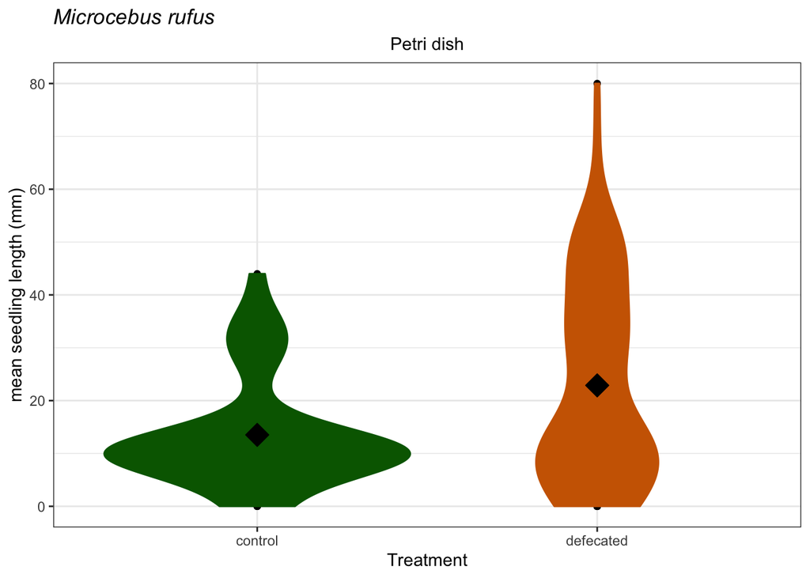

```r
ggplot(data = rufus_petri_yes, aes(x = treatment, y = seedling_mm)) +
  geom_point() + theme_bw() + geom_violin( aes(colour = treatment, fill = treatment)) +
  stat_summary(fun = mean, geom="point", shape=23, size=5, fill = "black") +
  labs(title = "Microcebus rufus",subtitle = "Petri dish",
       y = "mean seedling length (mm)", x = "Treatment") +
  theme(plot.title = element_text(face = "italic")) +
  theme(plot.subtitle = element_text(hjust = 0.5)) +
  scale_color_manual(values=c("darkgreen", "darkorange3")) +
  scale_fill_manual(values=c("darkgreen", "darkorange3")) +
  theme(legend.position = "None")
```

```r
# This caption is to be added later using word (as done in the original study)
#  N = 37(75) 51(75)
```

Here is the original figure

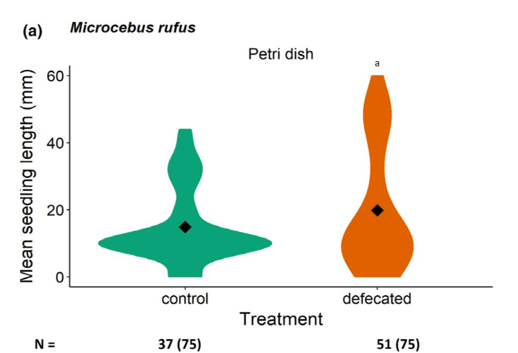

*Microcebus rufus violin graph*

Next I will graph the seedling length for each experiment done with seeds dispersed by *Microcebus jollyae*. This second graph is a series of three violin graphs together. It is complete with axis labels, a title and subtitles. I had to go through a lot of work to hide the y axis on two of them so that they would all fit together without excess information.

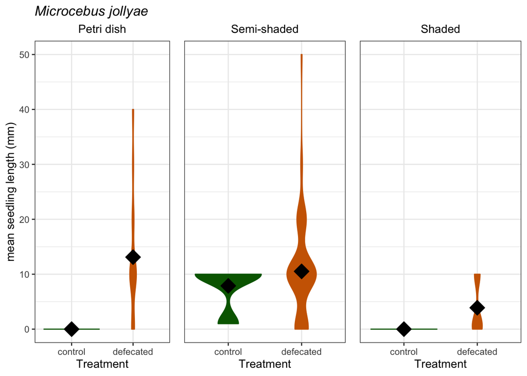

```r
# First we have the Petri dish experiment
plot1 <- ggplot(data = jollyae_petri_yes, aes(x = treatment, y = seedling_mm)) +
   theme_bw() + geom_violin( aes(colour = treatment, fill = treatment)) +
  stat_summary(fun = mean, geom="point", shape=23, size=5, fill = "black") +
  ylim(0,50) +
  labs(title = "Microcebus jollyae",subtitle = "Petri dish",
       y = "mean seedling length (mm)", x = "Treatment") +
  theme(plot.title = element_text(face = "italic")) +
  theme(plot.subtitle = element_text(hjust = 0.5)) +
  scale_color_manual(values=c("darkgreen", "darkorange3")) +
  scale_fill_manual(values=c("darkgreen", "darkorange3")) +
  theme(legend.position = "None")
# Next we have the semi-shaded plots
plot2 <- ggplot(data = jollyae_semi_yes, aes(x = treatment, y = seedling_mm)) +
   theme_bw() + geom_violin( aes(colour = treatment, fill = treatment)) +
  stat_summary(fun = mean, geom="point", shape=23, size=5, fill = "black") +
  ylim(0,50) +
  labs(title = "",subtitle = "Semi-shaded",
       y = "mean seedling length (mm)", x = "Treatment") +
  theme(plot.title = element_text(face = "italic")) +
  theme(plot.subtitle = element_text(hjust = 0.5)) +
  scale_color_manual(values=c("darkgreen", "darkorange3")) +
  scale_fill_manual(values=c("darkgreen", "darkorange3")) +
  theme(legend.position = "None") +
  theme(axis.text.y = element_blank(),
        axis.ticks.y = element_blank(),
        axis.title.y = element_blank())
# Then we have the shaded plots
plot3 <- ggplot(data = jollyae_closed_yes, aes(x = treatment, y = seedling_mm)) +
  theme_bw() + geom_violin( aes(colour = treatment, fill = treatment)) +
  stat_summary(fun = mean, geom="point", shape=23, size=5, fill = "black") +
  ylim(0,50) +
  labs(title = "",subtitle = "Shaded",
       y = "mean seedling length (mm)", x = "Treatment") +
  theme(plot.title = element_text(face = "italic")) +
  theme(plot.subtitle = element_text(hjust = 0.5)) +
  scale_color_manual(values=c("darkgreen", "darkorange3")) +
  scale_fill_manual(values=c("darkgreen", "darkorange3")) +
  theme(legend.position = "None") +
  theme(axis.text.y = element_blank(),
        axis.ticks.y = element_blank(),
        axis.title.y = element_blank())
# Now I will add them together
ggarrange(plot1, plot2, plot3, ncol = 3, nrow = 1)
```

```r
# Just like the first graph, a caption is to be added later using word (as done in the original study)
```

Here is the original figure

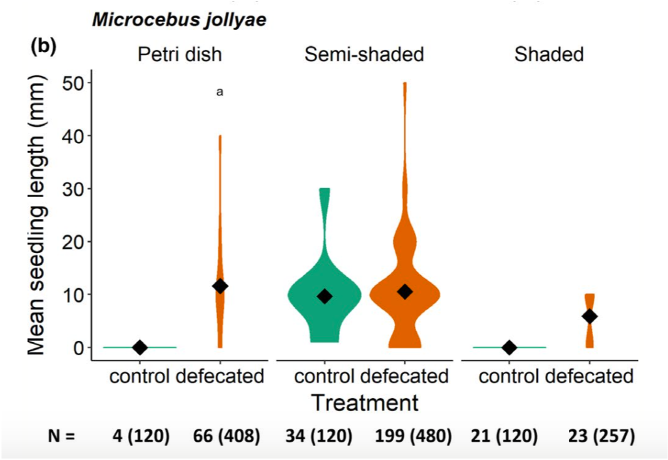

*Microcebus jollyae* violin graph

This replicated figure is quite different from the original. Most noteably, the control treatment for the semi-shaded plot does not have any values greater than 10. I went back into the original data and there are no data points >10. There also seem to be slight differences in the semi-shaded plot defecated treatment and the shaded-plot defecated treatment violin shapes probably due to different data.

## Mixed Effects Models Analysis

### Mean seedling length

I am starting with the mixed effect model comparing seedling length across the fixed effect of treatment and the random effect of species

Running the mixed effect model for rufus dispersed seeds in the petri dish experiment

The study did not tell me wether the random effects of the model were slope, intercept or slope and intercept. I tried all three for the first experiment.

```r
# REML = FALSE, intercept model
lme_rufus_petri_yes_summary_modified1 <- lmer(data = rufus_petri_yes_summary_modified, seedling_mean ~ treatment + (1 | scientificName), REML = FALSE)
summary(lme_rufus_petri_yes_summary_modified1)
```

```
## Linear mixed model fit by maximum likelihood  ['lmerMod']
## Formula: seedling_mean ~ treatment + (1 | scientificName)
##    Data: rufus_petri_yes_summary_modified
##
##      AIC      BIC   logLik deviance df.resid
##     70.7     71.1    -31.4     62.7        4
##
## Scaled residuals:
##     Min      1Q  Median      3Q     Max
## -1.1470 -0.8694  0.3526  0.5517  0.9216
##
## Random effects:
##  Groups         Name        Variance Std.Dev.
##  scientificName (Intercept) 110.08   10.492
##  Residual                    75.31    8.678
## Number of obs: 8, groups:  scientificName, 4
##
## Fixed effects:
##                    Estimate Std. Error t value
## (Intercept)          12.813      6.808   1.882
## treatmentdefecated   13.549      6.137   2.208
##
## Correlation of Fixed Effects:
##             (Intr)
## trtmntdfctd -0.451
```

```r
# REML = FALSE , slope model
# lme_rufus_petri_yes_summary_modified2 <- lmer(data = rufus_petri_yes_summary_modified, seedling_mean ~ treatment + (1 + treatment | scientificName), REML = FALSE)
# summary(lme_rufus_petri_yes_summary_modified2)
# will not run
```

The error given was:

Error: number of observations (=8) <= number of random effects (=8) for term (1 + treatment | scientificName); the random-effects parameters and the residual variance (or scale parameter) are probably unidentifiable

```r
# REML = FALSE , slope and intercept model
# lme_rufus_petri_yes_summary_modified3 <- lmer(data = rufus_petri_yes_summary_modified, seedling_mean ~ treatment + (1 | scientificName) + (1 + treatment | scientificName), REML = FALSE)
# summary(lme_rufus_petri_yes_summary_modified3)
# will not run
```

The error given was:

Error: number of observations (=8) <= number of random effects (=8) for term (1 + treatment | scientificName); the random-effects parameters and the residual variance (or scale parameter) are probably unidentifiable

Based on some research, the error is telling me that I do not have a sufficient number of observations to support a model which is this complex. I will only use intercept models for the rest of the analysis.

After we have determined the model we will use, we can get the other parameters by running statitical test

```r
null1 <- lmer(data = rufus_petri_yes_summary_modified, seedling_mean ~ 1 + (1 | scientificName), REML = FALSE)
summary(null1)
```

```
## Linear mixed model fit by maximum likelihood  ['lmerMod']
## Formula: seedling_mean ~ 1 + (1 | scientificName)
##    Data: rufus_petri_yes_summary_modified
##
##      AIC      BIC   logLik deviance df.resid
##     71.9     72.2    -33.0     65.9        5
##
## Scaled residuals:
##     Min      1Q  Median      3Q     Max
## -1.3863 -0.4493 -0.2848  0.4153  1.6154
##
## Random effects:
##  Groups         Name        Variance Std.Dev.
##  scientificName (Intercept)  64.19    8.012
##  Residual                   167.10   12.927
## Number of obs: 8, groups:  scientificName, 4
##
## Fixed effects:
##             Estimate Std. Error t value
## (Intercept)   19.587      6.077   3.223
```

```r
anova(null1, lme_rufus_petri_yes_summary_modified1, test = "Chisq")
```

```
## Data: rufus_petri_yes_summary_modified
## Models:
## null1: seedling_mean ~ 1 + (1 | scientificName)
## lme_rufus_petri_yes_summary_modified1: seedling_mean ~ treatment + (1 | scientificName)
##                                       npar    AIC    BIC  logLik deviance
## null1                                    3 71.932 72.170 -32.966   65.932
## lme_rufus_petri_yes_summary_modified1    4 70.744 71.062 -31.372   62.744
##                                        Chisq Df Pr(>Chisq)
## null1
## lme_rufus_petri_yes_summary_modified1 3.1876  1     0.0742 .
## ---
## Signif. codes:  0 '***' 0.001 '**' 0.01 '*' 0.05 '.' 0.1 ' ' 1
```

```r
r.squaredGLMM(lme_rufus_petri_yes_summary_modified1)
```

```
##            R2m       R2c
## [1,] 0.2205152 0.6833415
```

These are the statistics needed for the table

β = 13.549

z = 3.18796

p = 0.0742

R2M = 0.2205152

R2C = 0.6833415

Now I will run the rufus dispered forest ground experiment

```r
# lme_rufus_ground_yes_summary_modified1 <- lmer(data = rufus_ground_yes_summary_modified, seedling_mean ~ treatment + (1 | scientificName), REML = FALSE)
# summary(lme_rufus_ground_yes_summary_modified1)
```

It is impossible to do analysis with no more than one treatment

It is possible that the researchers ran the null model for this experiment

Now I will do the analysis for the the experiment from jollyae dispersed seeds in the petri dish

```r
# lme_jollyae_petri_yes_summary_modified1 <- lmer(data = jollyae_petri_yes_summary_modified, seedling_mean ~ treatment + (1 | scientificName), REML = FALSE)
# summary(lme_jollyae_petri_yes_summary_modified1)
```

seedling length = 0, cannot compare between treatments

It is possible that the researchers ran the null model for this experiment

Now I will do the analysis for the the experiment from jollyae dispersed seeds in the semi-shaded plot experiment

```r
lme_jollyae_semi_yes_summary_modified1 <- lmer(data = jollyae_semi_yes_summary_modified, seedling_mean ~ treatment + (1 | scientificName), REML = FALSE)
summary(lme_jollyae_semi_yes_summary_modified1)
```

```
## Linear mixed model fit by maximum likelihood  ['lmerMod']
## Formula: seedling_mean ~ treatment + (1 | scientificName)
##    Data: jollyae_semi_yes_summary_modified
##
##      AIC      BIC   logLik deviance df.resid
##     53.2     53.5    -22.6     45.2        4
##
## Scaled residuals:
##     Min      1Q  Median      3Q     Max
## -1.1760 -0.6877  0.1030  0.7142  0.9700
##
## Random effects:
##  Groups         Name        Variance Std.Dev.
##  scientificName (Intercept) 13.116   3.622
##  Residual                    8.017   2.831
## Number of obs: 8, groups:  scientificName, 4
##
## Fixed effects:
##                    Estimate Std. Error t value
## (Intercept)           5.500      2.299   2.393
## treatmentdefecated    1.774      2.002   0.886
##
## Correlation of Fixed Effects:
##             (Intr)
## trtmntdfctd -0.436
```

```r
null2 <- lmer(data = jollyae_semi_yes_summary_modified, seedling_mean ~ 1 + (1 | scientificName), REML = FALSE)
anova(null2, lme_jollyae_semi_yes_summary_modified1, test = "Chisq")
```

```
## Data: jollyae_semi_yes_summary_modified
## Models:
## null2: seedling_mean ~ 1 + (1 | scientificName)
## lme_jollyae_semi_yes_summary_modified1: seedling_mean ~ treatment + (1 | scientificName)
##                                        npar    AIC    BIC  logLik deviance
## null2                                     3 51.880 52.119 -22.940   45.880
## lme_jollyae_semi_yes_summary_modified1    4 53.164 53.482 -22.582   45.164
##                                         Chisq Df Pr(>Chisq)
## null2
## lme_jollyae_semi_yes_summary_modified1 0.7167  1     0.3972
```

```r
r.squaredGLMM(lme_jollyae_semi_yes_summary_modified1)
```

```
##             R2m      R2c
## [1,] 0.04079902 0.636132
```

These are the statistics needed for the table

β = 1.774

z = 0.7167

p = 0.3972

R2M = 0.04079902

R2C = 0.636132

Now I will do the analysis for the the experiment from jollyae dispersed seeds in the shaded plot experiment

```r
lme_jollyae_closed_yes_summary_modified1 <- lmer(data = jollyae_closed_yes_summary_modified, seedling_mean ~ treatment + (1 | scientificName), REML = FALSE)
summary(lme_jollyae_closed_yes_summary_modified1)
```

```
## Linear mixed model fit by maximum likelihood  ['lmerMod']
## Formula: seedling_mean ~ treatment + (1 | scientificName)
##    Data: jollyae_closed_yes_summary_modified
##
##      AIC      BIC   logLik deviance df.resid
##     24.5     22.1     -8.3     16.5        0
##
## Scaled residuals:
##     Min      1Q  Median      3Q     Max
## -1.4141 -0.3537  0.0000  0.3537  1.4141
##
## Random effects:
##  Groups         Name        Variance  Std.Dev.
##  scientificName (Intercept) 0.0005612 0.02369
##  Residual                   3.6444389 1.90904
## Number of obs: 4, groups:  scientificName, 2
##
## Fixed effects:
##                      Estimate Std. Error t value
## (Intercept)        -8.883e-16  1.350e+00   0.000
## treatmentdefecated  7.300e+00  1.909e+00   3.824
##
## Correlation of Fixed Effects:
##             (Intr)
## trtmntdfctd -0.707
```

```r
null3 <- lmer(data = jollyae_closed_yes_summary_modified, seedling_mean ~ 1 + (1 | scientificName), REML = FALSE)
```

```
## boundary (singular) fit: see ?isSingular
```

```r
anova(null3, lme_jollyae_closed_yes_summary_modified1, test = "Chisq")
```

```
## Data: jollyae_closed_yes_summary_modified
## Models:
## null3: seedling_mean ~ 1 + (1 | scientificName)
## lme_jollyae_closed_yes_summary_modified1: seedling_mean ~ treatment + (1 | scientificName)
##                                          npar    AIC    BIC   logLik deviance
## null3                                       3 28.677 26.836 -11.3384   22.677
## lme_jollyae_closed_yes_summary_modified1    4 24.525 22.070  -8.2625   16.525
##                                           Chisq Df Pr(>Chisq)
## null3
## lme_jollyae_closed_yes_summary_modified1 6.1518  1    0.01313 *
## ---
## Signif. codes:  0 '***' 0.001 '**' 0.01 '*' 0.05 '.' 0.1 ' ' 1
```

```r
r.squaredGLMM(lme_jollyae_closed_yes_summary_modified1)
```

```
##            R2m       R2c
## [1,] 0.8297392 0.8297654
```

These are the statistics needed for the table

β = 7.300

z = 6.1518

p = 0.01313

R2M = 0.8297392

R2C = 0.8297654

### Mean seedling length table

Now, I will construct a table with the replication values alongside the original values

Legend for table construction object:

Species: r = *Microcebus rufus*, j = *Microcebus jollyae*

Experiment: p = Petri dish, f = Forest ground, s = semi-shaded plot, c = shaded plot

Study: rep = replication, og = original

Model: n = Number of observations l = Seedling length, t = Germination time, r = germination rate, sur = survival analysis

```r
r_p_rep_l <- c("β = 13.549", "z = 3.18796", "p = 0.0742", "R2M = 0.2205152", "R2C = 0.6833415")
r_p_og_l <- c("β = 15.54", "z=2.45", "p<.1", "R2M = 0.21", "R2C = 0.76")

r_f_rep_l <- c("β = NA", "z = NA", "p = NA", "R2M = NA", "R2C = NA")
r_f_og_l <- c("β < 0.001", "z=1.00", "p = .48", "R2M = 0.25", "R2C = 0.25")

j_p_rep_l <- c("β = NA", "z = NA", "p = NA", "R2M = NA", "R2C = NA")
j_p_og_l <- c("β < 0.001", "z < 0.001", "p < .1", "R2M = 0.46", "R2C = 0.46")

j_s_rep_l <- c("β = 1.774", "z = 0.7167", "p = 0.3972", "R2M = 0.04079902", "R2C = 0.636132")
j_s_og_l <- c("β=1.08", "z=0.37", "p=.73", "R2M = 0.008", "R2C = 0.53")

j_c_rep_l <- c("β = 7.300", "z = 6.1518", "p = 0.01313", "R2M = 0.8297392", "R2C = 0.8297654")
j_c_og_l <- c("β < 0.001", "z=1.48", "p = .22", "R2M = 0.24", "R2C = 0.24")

t1_l <- cbind(r_p_rep_l, r_p_og_l, r_f_rep_l, r_f_og_l, j_p_rep_l,
              j_p_og_l, j_s_rep_l, j_s_og_l, j_c_rep_l, j_c_og_l)
t2_l <- as.data.frame(t1_l)
t3_l <- t2_l %>% gt() %>%
  cols_label(r_p_rep_l = "Petri dish experiment replication values",
             r_p_og_l = "Petri dish experiment original values",
             r_f_rep_l = "Forest ground experiment replication values",
             r_f_og_l = "Forest ground experiment original values",
             j_p_rep_l = "Petri dish experiment replication values",
             j_p_og_l = "Petri dish experiment original values",
             j_s_rep_l = "Semi-shaded plot experiment replication values",
             j_s_og_l = "Semi-shaded plot experiment original values",
             j_c_rep_l = "Shaded plot experiment replication values",
             j_c_og_l = "Shaded plot experiment original values") %>%
  tab_header(title = md("Summary table of the linear mixed-effects models of mean seedling length")) %>%
  tab_spanner(label = "Microcebus rufus", columns = c(r_p_rep_l, r_p_og_l, r_f_rep_l, r_f_og_l)) %>%
  tab_spanner(label = "Microcebus jollyae", columns = c(j_p_rep_l, j_p_og_l, j_s_rep_l, j_s_og_l, j_c_rep_l, j_c_og_l))
t3_l
```

Summary table of the linear mixed-effects models of mean seedling length

| Microcebus rufus Petri dish experiment replication values | Microcebus rufus Petri dish experiment original values | Microcebus rufus Forest ground experiment replication values | Microcebus rufus Forest ground experiment original values | Microcebus jollyae Petri dish experiment replication values | Microcebus jollyae Petri dish experiment original values | Microcebus jollyae Semi-shaded plot experiment replication values | Microcebus jollyae Semi-shaded plot experiment original values | Microcebus jollyae Shaded plot experiment replication values | Microcebus jollyae Shaded plot experiment original values |
| --- | --- | --- | --- | --- | --- | --- | --- | --- | --- |
| β = 13.549 | β = 15.54 | β = NA | β < 0.001 | β = NA | β < 0.001 | β = 1.774 | β=1.08 | β = 7.300 | β < 0.001 |
| z = 3.18796 | z=2.45 | z = NA | z=1.00 | z = NA | z < 0.001 | z = 0.7167 | z=0.37 | z = 6.1518 | z=1.48 |
| p = 0.0742 | p<.1 | p = NA | p = .48 | p = NA | p < .1 | p = 0.3972 | p=.73 | p = 0.01313 | p = .22 |
| R2M = 0.2205152 | R2M = 0.21 | R2M = NA | R2M = 0.25 | R2M = NA | R2M = 0.46 | R2M = 0.04079902 | R2M = 0.008 | R2M = 0.8297392 | R2M = 0.24 |
| R2C = 0.6833415 | R2C = 0.76 | R2C = NA | R2C = 0.25 | R2C = NA | R2C = 0.46 | R2C = 0.636132 | R2C = 0.53 | R2C = 0.8297654 | R2C = 0.24 |

This is the original table.

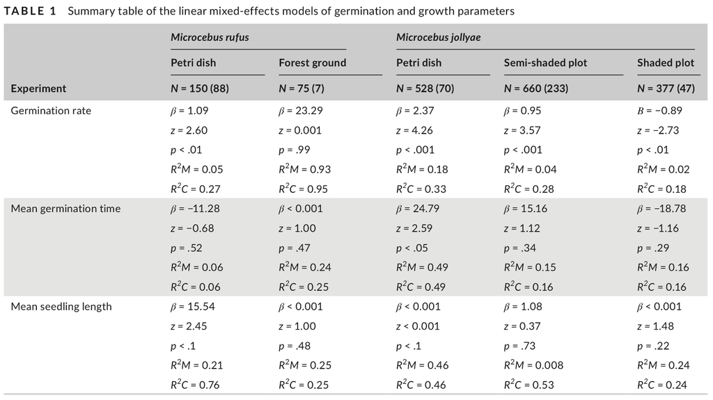

Unfortunately, the gt() package does not support multiple spanner titles. I chose to separate the different growth parameters because with both the replicaton and original values, the data would be overwhelming.

### Mean germination time

I will now code for the mixed effect model comparing germination time across the fixed effect of treatment and the random effect of species

Running the mixed effect model for rufus dispersed seeds in the petri dish experiment

```r
lme_rufus_petri_yes_summary_modified1_germ_time <- lmer(data = rufus_petri_yes_summary_modified, germ_time ~ treatment + (1 | scientificName), REML = FALSE)
```

```
## boundary (singular) fit: see ?isSingular
```

```r
summary(lme_rufus_petri_yes_summary_modified1_germ_time)
```

```
## Linear mixed model fit by maximum likelihood  ['lmerMod']
## Formula: germ_time ~ treatment + (1 | scientificName)
##    Data: rufus_petri_yes_summary_modified
##
##      AIC      BIC   logLik deviance df.resid
##     80.2     80.5    -36.1     72.2        4
##
## Scaled residuals:
##      Min       1Q   Median       3Q      Max
## -1.54881 -0.77281 -0.04597  0.84304  1.54370
##
## Random effects:
##  Groups         Name        Variance Std.Dev.
##  scientificName (Intercept)   0.0     0
##  Residual                   484.2    22
## Number of obs: 8, groups:  scientificName, 4
##
## Fixed effects:
##                    Estimate Std. Error t value
## (Intercept)           47.08      11.00   4.279
## treatmentdefecated   -15.97      15.56  -1.026
##
## Correlation of Fixed Effects:
##             (Intr)
## trtmntdfctd -0.707
## optimizer (nloptwrap) convergence code: 0 (OK)
## boundary (singular) fit: see ?isSingular
```

```r
null4 <- lmer(data = rufus_petri_yes_summary_modified, germ_time ~ 1 + (1 | scientificName), REML = FALSE)
```

```
## boundary (singular) fit: see ?isSingular
```

```r
anova(null4, lme_rufus_petri_yes_summary_modified1_germ_time, test = "Chisq")
```

```
## Data: rufus_petri_yes_summary_modified
## Models:
## null4: germ_time ~ 1 + (1 | scientificName)
## lme_rufus_petri_yes_summary_modified1_germ_time: germ_time ~ treatment + (1 | scientificName)
##                                                 npar    AIC    BIC  logLik
## null4                                              3 79.153 79.391 -36.576
## lme_rufus_petri_yes_summary_modified1_germ_time    4 80.163 80.481 -36.082
##                                                 deviance  Chisq Df Pr(>Chisq)
## null4                                             73.153
## lme_rufus_petri_yes_summary_modified1_germ_time   72.163 0.9894  1     0.3199
```

```r
r.squaredGLMM(lme_rufus_petri_yes_summary_modified1_germ_time)
```

```
##            R2m       R2c
## [1,] 0.1307745 0.1307745
```

These are the statistics needed for the table

β = -15.97

z = 0.9894

p = 0.3199

R2M = 0.1307745

R2C = 0.1307745

Not doing the analysis for Microcebus rufus forest ground experiment (see above)

Running the mixed effect model for jollyae dispersed seeds in the petri dish experiment

This model does not work

```r
# lme_jollyae_petri_yes_summary_modified1_germ_time <- lmer(data = jollyae_petri_yes_summary_modified, germ_time ~ treatment + (1 | scientificName), REML = FALSE)
# summary(lme_jollyae_petri_yes_summary_modified1_germ_time)
```

The error presented is: Error: grouping factors must have > 1 sampled level

So since it is the mean germination time, the comparison only has two points. I cannot run this analysis

Running the mixed effect model for jollyae dispersed seeds in the semi-shaded plot experiment

```r
lme_jollyae_semi_yes_summary_modified1_germ_time <- lmer(data = jollyae_semi_yes_summary_modified, germ_time ~ treatment + (1 | scientificName), REML = FALSE)
summary(lme_jollyae_semi_yes_summary_modified1_germ_time)
```

```
## Linear mixed model fit by maximum likelihood  ['lmerMod']
## Formula: germ_time ~ treatment + (1 | scientificName)
##    Data: jollyae_semi_yes_summary_modified
##
##      AIC      BIC   logLik deviance df.resid
##     70.8     71.1    -31.4     62.8        4
##
## Scaled residuals:
##     Min      1Q  Median      3Q     Max
## -1.6174 -0.3399  0.1509  0.4355  1.3156
##
## Random effects:
##  Groups         Name        Variance Std.Dev.
##  scientificName (Intercept)  56.05    7.487
##  Residual                   103.66   10.181
## Number of obs: 8, groups:  scientificName, 4
##
## Fixed effects:
##                    Estimate Std. Error t value
## (Intercept)          53.191      6.319   8.418
## treatmentdefecated   -5.183      7.199  -0.720
##
## Correlation of Fixed Effects:
##             (Intr)
## trtmntdfctd -0.570
```

```r
null5 <- lmer(data = jollyae_semi_yes_summary_modified, germ_time ~ 1 + (1 | scientificName), REML = FALSE)
anova(null5, lme_jollyae_semi_yes_summary_modified1_germ_time, test = "Chisq")
```

```
## Data: jollyae_semi_yes_summary_modified
## Models:
## null5: germ_time ~ 1 + (1 | scientificName)
## lme_jollyae_semi_yes_summary_modified1_germ_time: germ_time ~ treatment + (1 | scientificName)
##                                                  npar    AIC    BIC  logLik
## null5                                               3 69.252 69.490 -31.626
## lme_jollyae_semi_yes_summary_modified1_germ_time    4 70.764 71.082 -31.382
##                                                  deviance  Chisq Df Pr(>Chisq)
## null5                                              63.252
## lme_jollyae_semi_yes_summary_modified1_germ_time   62.764 0.4874  1     0.4851
```

```r
r.squaredGLMM(lme_jollyae_semi_yes_summary_modified1_germ_time)
```

```
##             R2m       R2c
## [1,] 0.04586151 0.3807093
```

These are the statistics needed for the table

β = -5.183

z = 0.4874

p = 0.4851

R2M = 0.04586151

R2C = 0.3807093

Running the mixed effect model for jollyae dispersed seeds in the shaded plot experiment

```r
lme_jollyae_closed_yes_summary_modified1_germ_time <- lmer(data = jollyae_closed_yes_summary_modified, germ_time ~ treatment + (1 | scientificName), REML = FALSE)
```

```
## boundary (singular) fit: see ?isSingular
```

```r
summary(lme_jollyae_closed_yes_summary_modified1_germ_time)
```

```
## Linear mixed model fit by maximum likelihood  ['lmerMod']
## Formula: germ_time ~ treatment + (1 | scientificName)
##    Data: jollyae_closed_yes_summary_modified
##
##      AIC      BIC   logLik deviance df.resid
##     34.7     32.3    -13.4     26.7        0
##
## Scaled residuals:
##     Min      1Q  Median      3Q     Max
## -1.1962 -0.8648  0.0000  0.8648  1.1962
##
## Random effects:
##  Groups         Name        Variance Std.Dev.
##  scientificName (Intercept)  0.00    0.000
##  Residual                   46.61    6.827
## Number of obs: 4, groups:  scientificName, 2
##
## Fixed effects:
##                    Estimate Std. Error t value
## (Intercept)         30.1667     4.8274   6.249
## treatmentdefecated   0.6833     6.8270   0.100
##
## Correlation of Fixed Effects:
##             (Intr)
## trtmntdfctd -0.707
## optimizer (nloptwrap) convergence code: 0 (OK)
## boundary (singular) fit: see ?isSingular
```

```r
null6 <- lmer(data = jollyae_closed_yes_summary_modified, germ_time ~ 1 + (1 | scientificName), REML = FALSE)
```

```
## boundary (singular) fit: see ?isSingular
```

```r
anova(null6, lme_jollyae_closed_yes_summary_modified1_germ_time, test = "Chisq")
```

```
## Data: jollyae_closed_yes_summary_modified
## Models:
## null6: germ_time ~ 1 + (1 | scientificName)
## lme_jollyae_closed_yes_summary_modified1_germ_time: germ_time ~ treatment + (1 | scientificName)
##                                                    npar    AIC    BIC  logLik
## null6                                                 3 32.729 30.888 -13.364
## lme_jollyae_closed_yes_summary_modified1_germ_time    4 34.719 32.264 -13.359
##                                                    deviance Chisq Df Pr(>Chisq)
## null6                                                26.729
## lme_jollyae_closed_yes_summary_modified1_germ_time   26.719  0.01  1     0.9203
```

```r
r.squaredGLMM(lme_jollyae_closed_yes_summary_modified1_germ_time)
```

```
##              R2m         R2c
## [1,] 0.003328367 0.003328367
```

These are the statistics needed for the table

β = 0.6833

z = 0.01

R2M = 0.003328367

R2C = 0.003328367

### Mean germination time table

Now, I will construct a table with the replication values alongside the original values

Legend for table construction object:

Species: r = *Microcebus rufus*, j = *Microcebus jollyae*

Experiment: p = Petri dish, f = Forest ground, s = semi-shaded plot, c = shaded plot

Study: rep = replication, og = original

Model: n = Number of observations l = Seedling length, t = Germination time, r = germination rate, sur = survival analysis

```r
r_p_rep_t <- c("β = -15.97", "z = 0.9894", "p = 0.3199", "R2M = 0.1307745", "R2C = 0.1307745")
r_p_og_t <- c("β = −11.28", "z = −0.68", "p = .52", "R2M = 0.06", "R2C = 0.06")

r_f_rep_t <- c("β = NA", "z = NA", "p = NA", "R2M = NA", "R2C = NA")
r_f_og_t <- c("β < 0.001", "z=1.00", "p = .47", "R2M = 0.24", "R2C = 0.25")

j_p_rep_t <- c("β = NA", "z = NA", "p = NA", "R2M = NA", "R2C = NA")
j_p_og_t <- c("β = 24.79", "z=2.59", "p < .05", "R2M = 0.49", "R2C = 0.49")

j_s_rep_t <- c("β = -5.183", "z = 0.4874","p = 0.4851", "R2M = 0.04586151", "R2C = 0.3807093")
j_s_og_t <- c("β = 15.16", "z=1.12", "p = .34", "R2M = 0.15", "R2C = 0.16")

j_c_rep_t <- c("β = 0.6833", "z = 0.01", "p = 0.923", "R2M = 0.00332", "R2C = 0.003328367")
j_c_og_t <- c("β = −18.78", "z = −1.16", "p = .29", "R2M = 0.16", "R2C = 0.16")

t1_t <- cbind(r_p_rep_t, r_p_og_t, r_f_rep_t, r_f_og_t, j_p_rep_t,
              j_p_og_t, j_s_rep_t, j_s_og_t, j_c_rep_t, j_c_og_t)
t2_t <- as.data.frame(t1_t)
t3_t <- t2_t %>% gt() %>%
  cols_label(r_p_rep_t = "Petri dish experiment replication values",
             r_p_og_t = "Petri dish experiment original values",
             r_f_rep_t = "Forest ground experiment replication values",
             r_f_og_t = "Forest ground experiment original values",
             j_p_rep_t = "Petri dish experiment replication values",
             j_p_og_t = "Petri dish experiment original values",
             j_s_rep_t = "Semi-shaded plot experiment replication values",
             j_s_og_t = "Semi-shaded plot experiment original values",
             j_c_rep_t = "Shaded plot experiment replication values",
             j_c_og_t = "Shaded plot experiment original values") %>%
  tab_header(title = md("Summary table of the linear mixed-effects models of mean germination time")) %>%
  tab_spanner(label = "Microcebus rufus", columns = c(r_p_rep_t, r_p_og_t, r_f_rep_t, r_f_og_t)) %>%
  tab_spanner(label = "Microcebus jollyae", columns = c(j_p_rep_t, j_p_og_t, j_s_rep_t, j_s_og_t, j_c_rep_t, j_c_og_t))
t3_t
```

Summary table of the linear mixed-effects models of mean germination time

[output not shown]

### Germination rate

I will now code for the mixed effect model comparing Germination ratio across the fixed effect of treatment and the random effect of species

First I will run the model for seeds dispersed by Microcebus rufus in the petri dish experiment.

This code calculates the ratios of germinated seeds for all the indivdual species.

```r
rufus_petri_ratio_summary <- rufus_petri %>%
  group_by(scientificName, treatment) %>%
  summarise( germ_ratio = mean(ratio),
            N = n())
rufus_petri_ratio_summary_modified <- rufus_petri_ratio_summary[-c(3, 4, 5, 6, 7, 8, 9, 10, 15), ]
```

Now for the model

```r
lme_rufus_petri_ratio_summary_modified <- lmer(data = rufus_petri_ratio_summary_modified, germ_ratio ~ treatment + (1 | scientificName), REML = FALSE)
summary(lme_rufus_petri_ratio_summary_modified)
```

```
## Linear mixed model fit by maximum likelihood  ['lmerMod']
## Formula: germ_ratio ~ treatment + (1 | scientificName)
##    Data: rufus_petri_ratio_summary_modified
##
##      AIC      BIC   logLik deviance df.resid
##      8.3      8.6     -0.1      0.3        4
##
## Scaled residuals:
##     Min      1Q  Median      3Q     Max
## -0.7168 -0.4998 -0.4090  0.1121  1.7666
##
## Random effects:
##  Groups         Name        Variance Std.Dev.
##  scientificName (Intercept) 0.02407  0.1552
##  Residual                   0.04104  0.2026
## Number of obs: 8, groups:  scientificName, 4
##
## Fixed effects:
##                    Estimate Std. Error t value
## (Intercept)          0.4833     0.1276   3.788
## treatmentdefecated   0.2451     0.1432   1.711
##
## Correlation of Fixed Effects:
##             (Intr)
## trtmntdfctd -0.561
```

```r
null7 <- lmer(data = rufus_petri_ratio_summary_modified, germ_ratio ~ 1 + (1 | scientificName), REML = FALSE)
anova(null7, lme_rufus_petri_ratio_summary_modified, test = "Chisq")
```

```
## Data: rufus_petri_ratio_summary_modified
## Models:
## null7: germ_ratio ~ 1 + (1 | scientificName)
## lme_rufus_petri_ratio_summary_modified: germ_ratio ~ treatment + (1 | scientificName)
##                                        npar    AIC    BIC   logLik deviance
## null7                                     3 8.4585 8.6968 -1.22926  2.45852
## lme_rufus_petri_ratio_summary_modified    4 8.2620 8.5798 -0.13099  0.26199
##                                         Chisq Df Pr(>Chisq)
## null7
## lme_rufus_petri_ratio_summary_modified 2.1965  1     0.1383
```

```r
r.squaredGLMM(lme_rufus_petri_ratio_summary_modified)
```

```
##            R2m       R2c
## [1,] 0.2085819 0.5011694
```

These are the statistics needed for the table

β = 0.2451

z = 2.1965

p = 0.1383

R2M = 0.2085819

R2C = 0.5011694

Now, I will run the model for seeds dispersed by Microcebus rufus in the forest ground experiment.

This code calculates the ratios of germinated seeds for all the indivdual species

```r
rufus_ground_ratio_summary <- rufus_ground %>%
  group_by(scientificName, treatment) %>%
  summarise( germ_ratio = mean(ratio),
             N = n())
rufus_ground_ratio_summary_modified <- rufus_ground_ratio_summary[-c(1, 2, 3, 8), ]
```

Now for the model

```r
lme_rufus_ground_ratio_summary_modified <- lmer(data = rufus_ground_ratio_summary_modified, germ_ratio ~ treatment + (1 | scientificName), REML = FALSE)
summary(lme_rufus_ground_ratio_summary_modified)
```

```
## Linear mixed model fit by maximum likelihood  ['lmerMod']
## Formula: germ_ratio ~ treatment + (1 | scientificName)
##    Data: rufus_ground_ratio_summary_modified
##
##      AIC      BIC   logLik deviance df.resid
##      7.4      5.0      0.3     -0.6        0
##
## Scaled residuals:
##     Min      1Q  Median      3Q     Max
## -1.4142 -0.3536  0.0000  0.3536  1.4142
##
## Random effects:
##  Groups         Name        Variance  Std.Dev.
##  scientificName (Intercept) 3.523e-06 0.001877
##  Residual                   5.062e-02 0.224981
## Number of obs: 4, groups:  scientificName, 2
##
## Fixed effects:
##                      Estimate Std. Error t value
## (Intercept)        -2.776e-17  1.591e-01   0.000
## treatmentdefecated  3.182e-01  2.250e-01   1.414
##
## Correlation of Fixed Effects:
##             (Intr)
## trtmntdfctd -0.707
```

```r
null8 <- lmer(data = rufus_ground_ratio_summary_modified, germ_ratio ~ 1 + (1 | scientificName), REML = FALSE)
```

```
## boundary (singular) fit: see ?isSingular
```

```r
anova(null8, lme_rufus_ground_ratio_summary_modified, test = "Chisq")
```

```
## Data: rufus_ground_ratio_summary_modified
## Models:
## null8: germ_ratio ~ 1 + (1 | scientificName)
## lme_rufus_ground_ratio_summary_modified: germ_ratio ~ treatment + (1 | scientificName)
##                                         npar    AIC    BIC   logLik deviance
## null8                                      3 7.0397 5.1986 -0.51986  1.03972
## lme_rufus_ground_ratio_summary_modified    4 7.4179 4.9630  0.29107 -0.58214
##                                          Chisq Df Pr(>Chisq)
## null8
## lme_rufus_ground_ratio_summary_modified 1.6219  1     0.2028
```

```r
r.squaredGLMM(lme_rufus_ground_ratio_summary_modified)
```

```
##      R2m       R2c
## [1,] 0.4 0.4000418
```

These are the statistics needed for the table

β = 3.182e-01

z = 1.6219

p = 0.2028

R2M = 0.4

R2C = 0.4000418

Now, I will run the model for seeds dispersed by Microcebus jollyae in the petri dish experiment. This code calculates the ratios of germinated seeds for all the indivdual species.

```r
jollyae_petri_ratio_summary <- jollyae_petri %>%
  group_by(scientificName, treatment) %>%
  summarise( germ_ratio = mean(ratio),
             N = n())
jollyae_petri_ratio_summary_modified <- jollyae_petri_ratio_summary
```

Now for the model

```r
lme_jollyae_petri_ratio_summary_modified <- lmer(data = jollyae_petri_ratio_summary_modified, germ_ratio ~ treatment + (1 | scientificName), REML = FALSE)
summary(lme_jollyae_petri_ratio_summary_modified)
```

```
## Linear mixed model fit by maximum likelihood  ['lmerMod']
## Formula: germ_ratio ~ treatment + (1 | scientificName)
##    Data: jollyae_petri_ratio_summary_modified
##
##      AIC      BIC   logLik deviance df.resid
##      1.8      2.1      3.1     -6.2        4
##
## Scaled residuals:
##     Min      1Q  Median      3Q     Max
## -1.5288 -0.4546 -0.2280  0.3277  1.9501
##
## Random effects:
##  Groups         Name        Variance Std.Dev.
##  scientificName (Intercept) 0.001708 0.04133
##  Residual                   0.025365 0.15926
## Number of obs: 8, groups:  scientificName, 4
##
## Fixed effects:
##                    Estimate Std. Error t value
## (Intercept)         0.05000    0.08227   0.608
## treatmentdefecated  0.26584    0.11262   2.361
##
## Correlation of Fixed Effects:
##             (Intr)
## trtmntdfctd -0.684
```

```r
null9 <- lmer(data = jollyae_petri_ratio_summary_modified, germ_ratio ~ 1 + (1 | scientificName), REML = FALSE)
```

```
## boundary (singular) fit: see ?isSingular
```

```r
anova(null9, lme_jollyae_petri_ratio_summary_modified, test = "Chisq")
```

```
## Data: jollyae_petri_ratio_summary_modified
## Models:
## null9: germ_ratio ~ 1 + (1 | scientificName)
## lme_jollyae_petri_ratio_summary_modified: germ_ratio ~ treatment + (1 | scientificName)
##                                          npar    AIC    BIC logLik deviance
## null9                                       3 3.8481 4.0864 1.0759  -2.1519
## lme_jollyae_petri_ratio_summary_modified    4 1.8133 2.1311 3.0934  -6.1867
##                                           Chisq Df Pr(>Chisq)
## null9
## lme_jollyae_petri_ratio_summary_modified 4.0348  1    0.04457 *
## ---
## Signif. codes:  0 '***' 0.001 '**' 0.01 '*' 0.05 '.' 0.1 ' ' 1
```

```r
r.squaredGLMM(lme_jollyae_petri_ratio_summary_modified)
```

```
##          R2m       R2c
## [1,] 0.42721 0.4633437
```

These are the statistics needed for the table

β = 0.26584

z = 4.0348

p = 0.04457

R2M = 0.42721

R2C = 0.4633437

Now I will run the model for seeds dispersed by Microcebus jollyae in the semi-shaded experiment, This code calculates the ratios of germinated seeds for all the indivdual species.

```r
jollyae_semi_ratio_summary <- jollyae_semi %>%
  group_by(scientificName, treatment) %>%
  summarise( germ_ratio = mean(ratio),
             N = n())
jollyae_semi_ratio_summary_modified <- jollyae_semi_ratio_summary
```

Now for the model

```r
lme_jollyae_semi_ratio_summary_modified <- lmer(data = jollyae_semi_ratio_summary_modified, germ_ratio ~ treatment + (1 | scientificName), REML = FALSE)
summary(lme_jollyae_semi_ratio_summary_modified)
```

```
## Linear mixed model fit by maximum likelihood  ['lmerMod']
## Formula: germ_ratio ~ treatment + (1 | scientificName)
##    Data: jollyae_semi_ratio_summary_modified
##
##      AIC      BIC   logLik deviance df.resid
##      3.0      3.3      2.5     -5.0        4
##
## Scaled residuals:
##     Min      1Q  Median      3Q     Max
## -1.1532 -0.3906 -0.1640  0.3141  1.1768
##
## Random effects:
##  Groups         Name        Variance Std.Dev.
##  scientificName (Intercept) 0.05445  0.23335
##  Residual                   0.00840  0.09165
## Number of obs: 8, groups:  scientificName, 4
##
## Fixed effects:
##                    Estimate Std. Error t value
## (Intercept)         0.34167    0.12535   2.726
## treatmentdefecated  0.18646    0.06481   2.877
##
## Correlation of Fixed Effects:
##             (Intr)
## trtmntdfctd -0.259
```

```r
null10 <- lmer(data = jollyae_semi_ratio_summary_modified, germ_ratio ~ 1 + (1 | scientificName), REML = FALSE)
anova(null10, lme_jollyae_semi_ratio_summary_modified, test = "Chisq")
```

```
## Data: jollyae_semi_ratio_summary_modified
## Models:
## null10: germ_ratio ~ 1 + (1 | scientificName)
## lme_jollyae_semi_ratio_summary_modified: germ_ratio ~ treatment + (1 | scientificName)
##                                         npar    AIC    BIC  logLik deviance
## null10                                     3 5.4991 5.7374 0.25047  -0.5009
## lme_jollyae_semi_ratio_summary_modified    4 3.0131 3.3309 2.49346  -4.9869
##                                         Chisq Df Pr(>Chisq)
## null10
## lme_jollyae_semi_ratio_summary_modified 4.486  1    0.03417 *
## ---
## Signif. codes:  0 '***' 0.001 '**' 0.01 '*' 0.05 '.' 0.1 ' ' 1
```

```r
r.squaredGLMM(lme_jollyae_semi_ratio_summary_modified)
```

```
##            R2m       R2c
## [1,] 0.1364723 0.8845932
```

These are the statistics needed for the table

β = 0.18646

z = 4.486

p = 0.03417

R2M = 0.1364723

R2C = 0.8845932

Now I will run the model for seeds dispersed by Microcebus jollyae in the shaded experiment.

This code calculates the ratios of germinated seeds for all the indivdual species.

```r
jollyae_closed_ratio_summary <- jollyae_closed %>%
  group_by(scientificName, treatment) %>%
  summarise( germ_ratio = mean(ratio),
             N = n())
jollyae_closed_ratio_summary_modified <- jollyae_closed_ratio_summary[-c(5), ]
```

Now for the model

```r
lme_jollyae_closed_ratio_summary_modified <- lmer(data = jollyae_closed_ratio_summary_modified, germ_ratio ~ treatment + (1 | scientificName), REML = FALSE)
summary(lme_jollyae_closed_ratio_summary_modified)
```

```
## Linear mixed model fit by maximum likelihood  ['lmerMod']
## Formula: germ_ratio ~ treatment + (1 | scientificName)
##    Data: jollyae_closed_ratio_summary_modified
##
##      AIC      BIC   logLik deviance df.resid
##      0.1      0.4      4.0     -7.9        4
##
## Scaled residuals:
##     Min      1Q  Median      3Q     Max
## -0.7971 -0.7290 -0.4850  0.4115  1.6868
##
## Random effects:
##  Groups         Name        Variance Std.Dev.
##  scientificName (Intercept) 0.001569 0.0396
##  Residual                   0.020190 0.1421
## Number of obs: 8, groups:  scientificName, 4
##
## Fixed effects:
##                     Estimate Std. Error t value
## (Intercept)         0.125000   0.073755   1.695
## treatmentdefecated -0.008769   0.100475  -0.087
##
## Correlation of Fixed Effects:
##             (Intr)
## trtmntdfctd -0.681
```

```r
null11 <- lmer(data = jollyae_closed_ratio_summary_modified, germ_ratio ~ 1 + (1 | scientificName), REML = FALSE)
anova(null11, lme_jollyae_closed_ratio_summary_modified, test = "Chisq")
```

```
## Data: jollyae_closed_ratio_summary_modified
## Models:
## null11: germ_ratio ~ 1 + (1 | scientificName)
## lme_jollyae_closed_ratio_summary_modified: germ_ratio ~ treatment + (1 | scientificName)
##                                           npar      AIC      BIC logLik
## null11                                       3 -1.93203 -1.69371 3.9660
## lme_jollyae_closed_ratio_summary_modified    4  0.06036  0.37812 3.9698
##                                           deviance  Chisq Df Pr(>Chisq)
## null11                                     -7.9320
## lme_jollyae_closed_ratio_summary_modified  -7.9396 0.0076  1     0.9305
```

```r
r.squaredGLMM(lme_jollyae_closed_ratio_summary_modified)
```

```
##             R2m        R2c
## [1,] 0.00100877 0.07302369
```

These are the statistics needed for the table

β = -0.008769

z = 0.0076

p = 0.9305

R2M = 0.00100877

R2C = 0.07302369

### Germination rate table

Now, I will construct a table with the replication values alongside the original values

Legend for table construction object:

Species: r = *Microcebus rufus*, j = *Microcebus jollyae*

Experiment: p = Petri dish, f = Forest ground, s = semi-shaded plot, c = shaded plot

Study: rep = replication, og = original

Model: n = Number of observations l = Seedling length, t = Germination time, r = germination rate, sur = survival analysis

```r
r_p_rep_r <- c("β = 0.2451", "z = 2.1965", "p = 0.1383", "R2M = 0.2085819", "R2C = 0.5011694")
r_p_og_r <- c("β = 1.09", "z= 2.60", "p<.01", "R2M = 0.05", "R2C = 0.27")

r_f_rep_r <- c("β = 3.182e-01", "z = 1.6219", "p = 0.2028", "R2M = 0.4", "R2C = 0.4000418")
r_f_og_r <- c("β = 23.29", "z=0.001", "p = .99", "R2M = 0.93", "R2C = 0.95")

j_p_rep_r <- c("β = 0.26584", "z = 4.0348", "p = 0.04457", "R2M = 0.42721", "R2C = 0.4633437")
j_p_og_r <- c("β = 2.37", "z=4.26", "p < .001", "R2M = 0.18", "R2C = 0.33")

j_s_rep_r <- c( "β = 0.18646", "z = 4.486", "p = 0.03417", "R2M = 0.1364723", "R2C = 0.8845932")
j_s_og_r <- c("β = 0.95", "z=3.57", "p<.001", "R2M = 0.04", "R2C = 0.28")

j_c_rep_r <- c("β = -0.008769", "z = 0.0076", "p = 0.9305", "R2M = 0.00100877", "R2C = 0.07302369")
j_c_og_r <- c("β = −0.89", "z=−2.73", "p < .01", "R2M = 0.02", "R2C = 0.18")

t1_r <- cbind(r_p_rep_r, r_p_og_r, r_f_rep_r, r_f_og_r, j_p_rep_r,
              j_p_og_r, j_s_rep_r, j_s_og_r, j_c_rep_r, j_c_og_r)
t2_r <- as.data.frame(t1_r)
t3_r <- t2_r %>% gt() %>%
  cols_label(r_p_rep_r = "Petri dish experiment replication values",
             r_p_og_r = "Petri dish experiment original values",
             r_f_rep_r = "Forest ground experiment replication values",
             r_f_og_r = "Forest ground experiment original values",
             j_p_rep_r = "Petri dish experiment replication values",
             j_p_og_r = "Petri dish experiment original values",
             j_s_rep_r = "Semi-shaded plot experiment replication values",
             j_s_og_r = "Semi-shaded plot experiment original values",
             j_c_rep_r = "Shaded plot experiment replication values",
             j_c_og_r = "Shaded plot experiment original values") %>%
  tab_header(title = md("Summary table of the linear mixed-effects models of germination rate")) %>%
  tab_spanner(label = "Microcebus rufus", columns = c(r_p_rep_r, r_p_og_r, r_f_rep_r, r_f_og_r)) %>%
  tab_spanner(label = "Microcebus jollyae", columns = c(j_p_rep_r, j_p_og_r, j_s_rep_r, j_s_og_r, j_c_rep_r, j_c_og_r))
t3_r
```

Summary table of the linear mixed-effects models of germination rate

| Microcebus rufus Petri dish experiment replication values | Microcebus rufus Petri dish experiment original values | Microcebus rufus Forest ground experiment replication values | Microcebus rufus Forest ground experiment original values | Microcebus jollyae Petri dish experiment replication values | Microcebus jollyae Petri dish experiment original values | Microcebus jollyae Semi-shaded plot experiment replication values | Microcebus jollyae Semi-shaded plot experiment original values | Microcebus jollyae Shaded plot experiment replication values | Microcebus jollyae Shaded plot experiment original values |
| --- | --- | --- | --- | --- | --- | --- | --- | --- | --- |
| β = 0.2451 | β = 1.09 | β = 3.182e-01 | β = 23.29 | β = 0.26584 | β = 2.37 | β = 0.18646 | β = 0.95 | β = -0.008769 | β = −0.89 |
| z = 2.1965 | z= 2.60 | z = 1.6219 | z=0.001 | z = 4.0348 | z=4.26 | z = 4.486 | z=3.57 | z = 0.0076 | z=−2.73 |
| p = 0.1383 | p<.01 | p = 0.2028 | p = .99 | p = 0.04457 | p < .001 | p = 0.03417 | p<.001 | p = 0.9305 | p < .01 |
| R2M = 0.2085819 | R2M = 0.05 | R2M = 0.4 | R2M = 0.93 | R2M = 0.42721 | R2M = 0.18 | R2M = 0.1364723 | R2M = 0.04 | R2M = 0.00100877 | R2M = 0.02 |
| R2C = 0.5011694 | R2C = 0.27 | R2C = 0.4000418 | R2C = 0.95 | R2C = 0.4633437 | R2C = 0.33 | R2C = 0.8845932 | R2C = 0.28 | R2C = 0.07302369 | R2C = 0.18 |

## Survival analysis

This is the survival analysis for seeds dispersed by microcebus rufus in the petri dish experiment

```r
# Creating a status colum to indicate that all of the seeds germinated at some point
rufus_petri_yes$status <- rep(1, times = 121, length.out = NA, each = 1)

# Next we use the survival function to make a survival curve
rufus_petri_yes_km_fit <- survfit(Surv(germ_time, status) ~ treatment, data = rufus_petri_yes)
# This give a nice summary of the analysis
summary(rufus_petri_yes_km_fit, times = c(1,15,30,45,60,75,90))
```

```
## Call: survfit(formula = Surv(germ_time, status) ~ treatment, data = rufus_petri_yes)
##
## 3 observations deleted due to missingness
##                 treatment=control
##  time n.risk n.event survival std.err lower 95% CI upper 95% CI
##     1     37       0    1.000  0.0000        1.000        1.000
##    15     33       4    0.892  0.0510        0.797        0.998
##    30     30       3    0.811  0.0644        0.694        0.947
##    45     28       2    0.757  0.0705        0.630        0.908
##    60     26       2    0.703  0.0751        0.570        0.867
##    75     14      12    0.378  0.0797        0.250        0.572
##    90     10       4    0.270  0.0730        0.159        0.459
##
##                 treatment=defecated
##  time n.risk n.event survival std.err lower 95% CI upper 95% CI
##     1     81       0   1.0000  0.0000       1.0000        1.000
##    15     78       3   0.9630  0.0210       0.9227        1.000
##    30     52      27   0.6296  0.0537       0.5328        0.744
##    45     17      34   0.2099  0.0452       0.1375        0.320
##    60      6      11   0.0741  0.0291       0.0343        0.160
##    75      4       2   0.0494  0.0241       0.0190        0.128
```

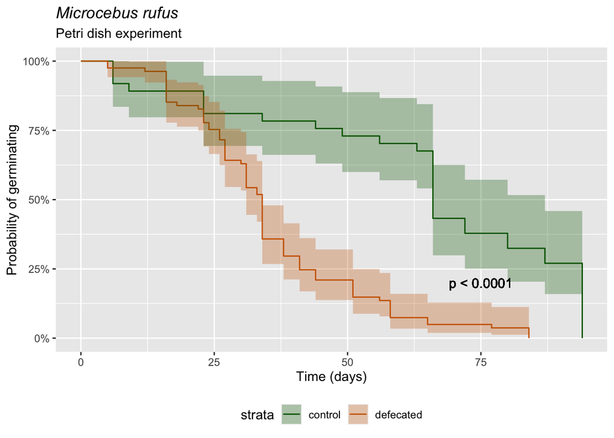

```r
# Next we plot the survival fit and make it look like the graph in the paper
rufus_petri_yes_km_plot <- autoplot(rufus_petri_yes_km_fit)
rufus_petri_yes_km_plot + labs(title = "Microcebus rufus",subtitle = "Petri dish experiment",
                           y = "Probability of germinating", x = "Time (days)") +
  theme(plot.title = element_text(face = "italic")) +
  scale_color_manual(values=c("darkgreen", "darkorange3")) +
  scale_fill_manual(values=c("darkgreen", "darkorange3")) +
  geom_text(x=75, y=.2, label="p < 0.0001") + theme(legend.position="bottom")
```

One problem though is that this graph is upside down. I used scale_y_reverse() to reverse the scale, but now the numbers are wrong and the annotated p value is gone.

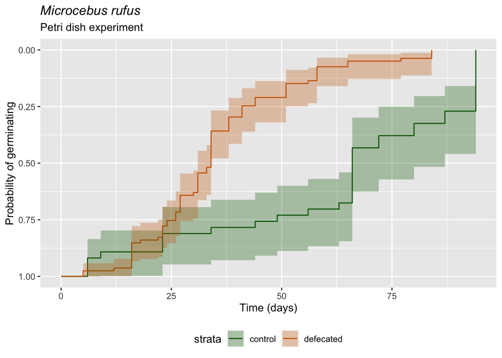

```r
rufus_petri_yes_km_plot + labs(title = "Microcebus rufus",subtitle = "Petri dish experiment",
                               y = "Probability of germinating", x = "Time (days)") +
  theme(plot.title = element_text(face = "italic")) +
  scale_color_manual(values=c("darkgreen", "darkorange3")) +
  scale_fill_manual(values=c("darkgreen", "darkorange3")) +
  geom_text(x=75, y=.75, label="p < 0.0001") + theme(legend.position="bottom") + scale_y_reverse()
```

I am unable to flip the axises or re-add the p-value to the graph

Here is the original graph.

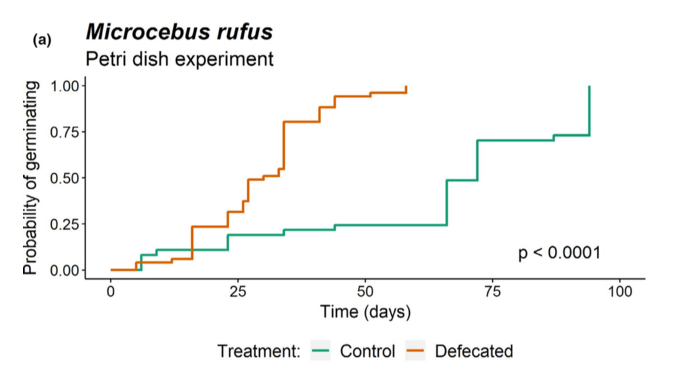

*Microcebus rufus* survival graph for the petri dish experiment

This the the Cox test with fragility. The summary includes the Chi square value, the degrees of freedom and the p-value.

```r
rufus_petri_yes_cox <- coxph(Surv(germ_time, status) ~ treatment, data=rufus_petri_yes)
summary(rufus_petri_yes_cox)
```

```
## Call:
## coxph(formula = Surv(germ_time, status) ~ treatment, data = rufus_petri_yes)
##
##   n= 118, number of events= 118
##    (3 observations deleted due to missingness)
##
##                      coef exp(coef) se(coef)     z Pr(>|z|)
## treatmentdefecated 1.4755    4.3734   0.2483 5.942 2.81e-09 ***
## ---
## Signif. codes:  0 '***' 0.001 '**' 0.01 '*' 0.05 '.' 0.1 ' ' 1
##
##                    exp(coef) exp(-coef) lower .95 upper .95
## treatmentdefecated     4.373     0.2287     2.688     7.115
##
## Concordance= 0.629  (se = 0.028 )
## Likelihood ratio test= 41.38  on 1 df,   p=1e-10
## Wald test            = 35.31  on 1 df,   p=3e-09
## Score (logrank) test = 39.11  on 1 df,   p=4e-10
```

These are the statistics needed for the table

X^2 = 41.38

df = 1

p = 1e-10

This is the survival analysis for seeds dispersed by microcebus rufus in the forest ground experiment

```r
#Creating a status colum to indicate that all of the seeds germinated at some point
rufus_ground_yes$status <- rep(1, times = 7, length.out = NA, each = 1)
# Next we use the survival function to make a survival curve
rufus_ground_yes_km_fit <- survfit(Surv(germ_time, status) ~ 1, data = rufus_ground_yes)
# This gives a nice summary of the analysis
summary(rufus_ground_yes_km_fit, times = c(1,15,30,45,60,75,90))
```

```
## Call: survfit(formula = Surv(germ_time, status) ~ 1, data = rufus_ground_yes)
##
##  time n.risk n.event survival std.err lower 95% CI upper 95% CI
##     1      7       0    1.000   0.000        1.000            1
##    15      7       0    1.000   0.000        1.000            1
##    30      4       3    0.571   0.187        0.301            1
```

Next we plot the survival fit and make it look like the graph in the paper

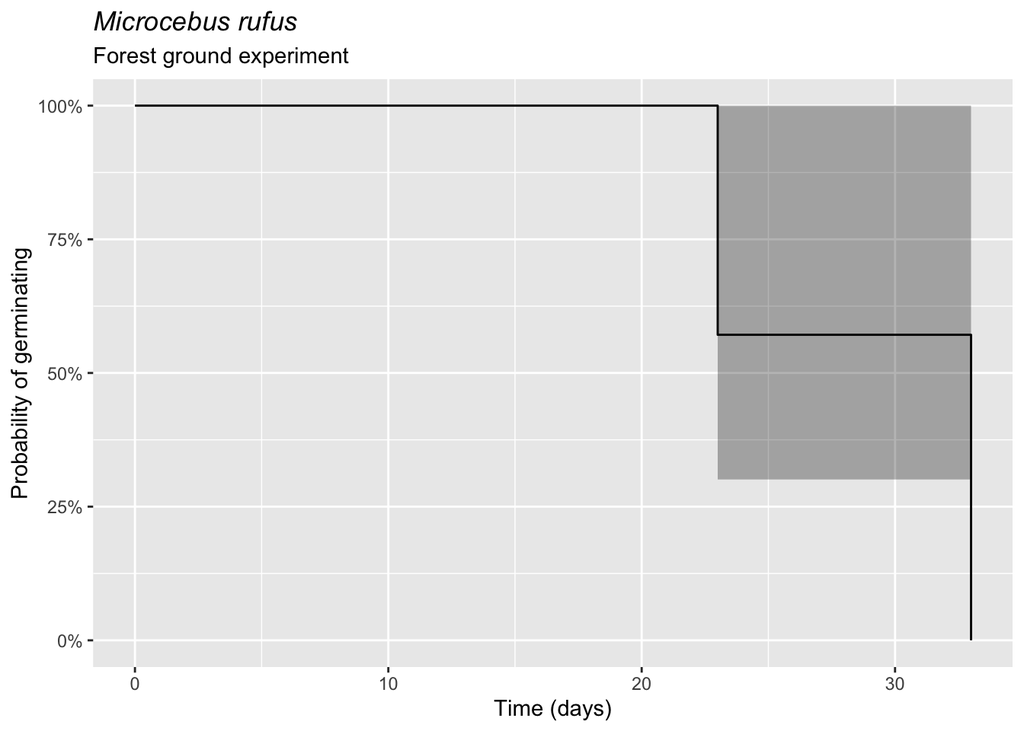

```r
rufus_ground_yes_km_plot <- autoplot(rufus_ground_yes_km_fit)
rufus_ground_yes_km_plot + labs(title = "Microcebus rufus",subtitle = "Forest ground experiment",
                               y = "Probability of germinating", x = "Time (days)") +
  theme(plot.title = element_text(face = "italic")) +
  scale_color_manual(values=c("darkorange3")) +
  scale_fill_manual(values=c("darkorange3")) + theme(legend.position="bottom")
```

Unfortunately it does not have color

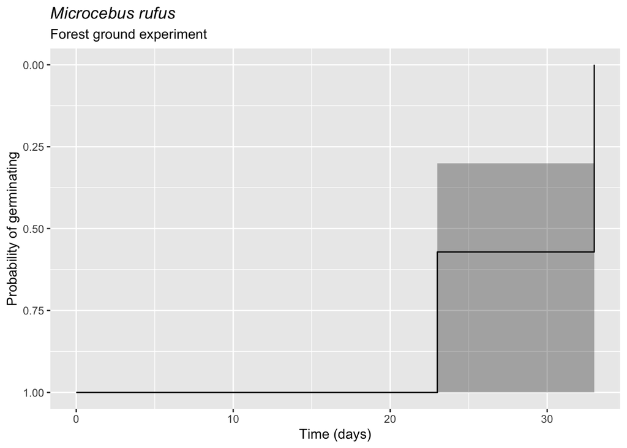

```r
rufus_ground_yes_km_plot + labs(title = "Microcebus rufus",subtitle = "Forest ground experiment",
                               y = "Probability of germinating", x = "Time (days)") +
  theme(plot.title = element_text(face = "italic")) +
  scale_color_manual(values=c("darkorange3")) +
  scale_fill_manual(values=c( "darkorange3")) + theme(legend.position="bottom") + scale_y_reverse()
```

Here is the original graph

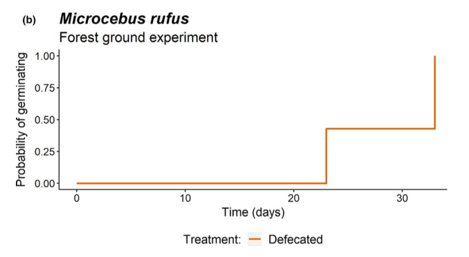

*Microcebus rufus* survival graph for the forest ground experiment

There is no chi square analysis for the Microcebus rufus forest ground experiment because there is only one treatment

This is the survival analysis for seeds dispersed by microcebus jollyae in the petri dish experiment

```r
# Creating a status colum to indicate that all of the seeds germinated at some point
jollyae_petri_yes$status <- rep(1, times = 70, length.out = NA, each = 1)

# Next we use the survival function to make a survival curve
jollyae_petri_yes_km_fit <- survfit(Surv(germ_time, status) ~ treatment, data = jollyae_petri_yes)
# This give a nice summary of the analysis
summary(jollyae_petri_yes_km_fit, times = c(1,15,30,45,60,75,90))
```

```
## Call: survfit(formula = Surv(germ_time, status) ~ treatment, data = jollyae_petri_yes)
##
##                 treatment=control
##  time n.risk n.event survival std.err lower 95% CI upper 95% CI
##     1      4       0        1       0            1            1
##    15      4       0        1       0            1            1
##    30      4       4        0     NaN           NA           NA
##
##                 treatment=defecated
##  time n.risk n.event survival std.err lower 95% CI upper 95% CI
##     1     66       0   1.0000  0.0000       1.0000        1.000
##    15     61       5   0.9242  0.0326       0.8626        0.990
##    30     28      37   0.3636  0.0592       0.2643        0.500
##    45      5      19   0.0758  0.0326       0.0326        0.176
##    60      5       0   0.0758  0.0326       0.0326        0.176
##    75      3       2   0.0455  0.0256       0.0150        0.137
```

Unfortunetly, it is impossible to plot this next graph. The error “Error: Aesthetics can not vary with a ribbon” makes it impossible for graph to be graphed. I researched this error and could not find the solution.

```r
# jollyae_petri_yes_km_plot <- autoplot(jollyae_petri_yes_km_fit)
# jollyae_petri_yes_km_plot
```

Here is the original graph

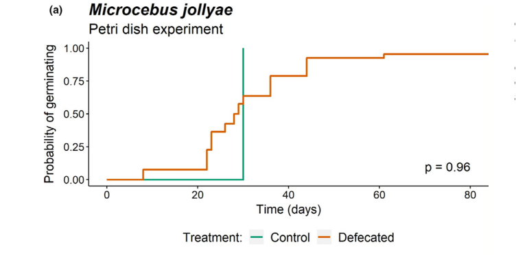

*Microcebus jollyae* survival graph for the petri dish experiment

This the the Cox test with fragility. The summary includes the Chi square value, the degrees of freedom and the p-value

```r
jollyae_petri_yes_cox <- coxph(Surv(germ_time, status) ~ treatment, data=jollyae_petri_yes)
summary(jollyae_petri_yes_cox)
```

```
## Call:
## coxph(formula = Surv(germ_time, status) ~ treatment, data = jollyae_petri_yes)
##
##   n= 70, number of events= 70
##
##                        coef exp(coef) se(coef)      z Pr(>|z|)
## treatmentdefecated -0.08362   0.91978  0.52513 -0.159    0.873
##
##                    exp(coef) exp(-coef) lower .95 upper .95
## treatmentdefecated    0.9198      1.087    0.3286     2.574
##
## Concordance= 0.487  (se = 0.009 )
## Likelihood ratio test= 0.02  on 1 df,   p=0.9
## Wald test            = 0.03  on 1 df,   p=0.9
## Score (logrank) test = 0.03  on 1 df,   p=0.9
```

These are the statistics needed for the table

X^2 = 0.02

df = 1

p = 0.9

This is the survival analysis for seeds dispersed by microcebus jollyae in the semi-shaded plot experiment

```r
# Creating a status colum to indicate that all of the seeds germinated at some point
jollyae_semi_yes$status <- rep(1, times = 233, length.out = NA, each = 1)
# Next we use the survival function to make a survival curve
jollyae_semi_yes_km_fit <- survfit(Surv(germ_time, status) ~ treatment, data = jollyae_semi_yes)
# This give a nice summary of the analysis
summary(jollyae_semi_yes_km_fit, times = c(1,15,30,45,60,75,90))
```

```
## Call: survfit(formula = Surv(germ_time, status) ~ treatment, data = jollyae_semi_yes)
##
##                 treatment=control
##  time n.risk n.event survival std.err lower 95% CI upper 95% CI
##     1     34       0   1.0000  0.0000       1.0000        1.000
##    15     34       0   1.0000  0.0000       1.0000        1.000
##    30     29       5   0.8529  0.0607       0.7418        0.981
##    45     21       8   0.6176  0.0833       0.4741        0.805
##    60      3      18   0.0882  0.0486       0.0299        0.260
##
##                 treatment=defecated
##  time n.risk n.event survival std.err lower 95% CI upper 95% CI
##     1    199       0   1.0000 0.00000       1.0000       1.0000
##    15    189      10   0.9497 0.01549       0.9199       0.9806
##    30    161      28   0.8090 0.02786       0.7562       0.8655
##    45    135      37   0.6231 0.03435       0.5593       0.6942
##    60     19     105   0.0955 0.02083       0.0623       0.1464
##    75     10       9   0.0503 0.01549       0.0275       0.0919
##    90      3       7   0.0151 0.00864       0.0049       0.0463
```

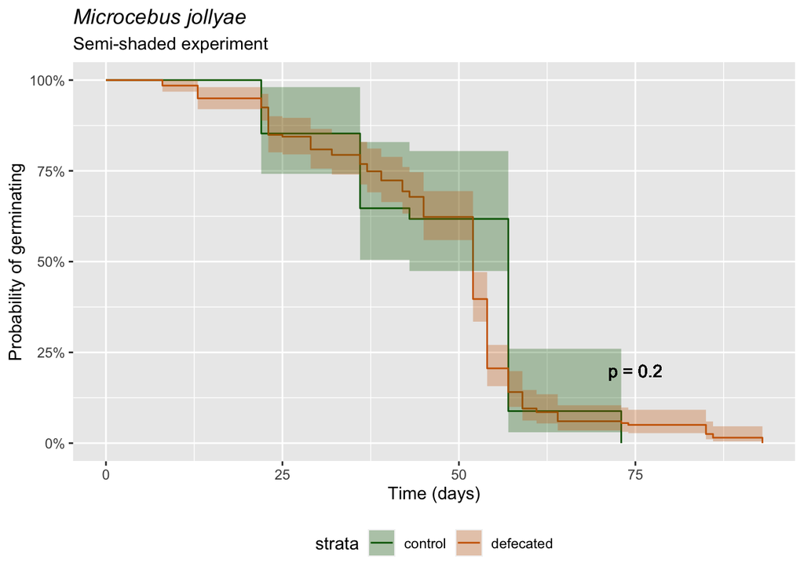

```r
# Next we plot the survival fit and make it look like the graph in the paper
jollyae_semi_yes_km_plot <- autoplot(jollyae_semi_yes_km_fit)
jollyae_semi_yes_km_plot + labs(title = "Microcebus jollyae",subtitle = "Semi-shaded experiment",
                                 y = "Probability of germinating", x = "Time (days)") +
  theme(plot.title = element_text(face = "italic")) +
  scale_color_manual(values=c("darkgreen", "darkorange3")) +
  scale_fill_manual(values=c("darkgreen", "darkorange3")) +
  geom_text(x=75, y=.2, label="p = 0.2") + theme(legend.position="bottom")
```

One problem though is that this graph is upside down. I used scale_y_reverse() to reverse the scale, but now the numbers are wrong and the annotated p value is gone.

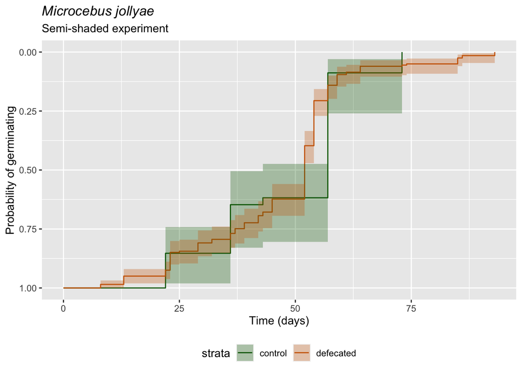

```r
jollyae_semi_yes_km_plot + labs(title = "Microcebus jollyae",subtitle = "Semi-shaded experiment",
                                 y = "Probability of germinating", x = "Time (days)") +
  theme(plot.title = element_text(face = "italic")) +
  scale_color_manual(values=c("darkgreen", "darkorange3")) +
  scale_fill_manual(values=c("darkgreen", "darkorange3")) +
  geom_text(x=75, y=.75, label="p = 0.2") + theme(legend.position="bottom") + scale_y_reverse()
```

Here is the original graph

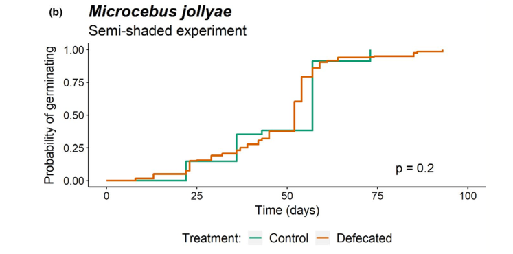

*Microcebus jollyae* survival graph for the semi-shaded plot experiment

This the the Cox test with fragility. The summary includes the Chi square value, the degrees of freedom and the p-value.

```r
jollyae_semi_yes_cox <- coxph(Surv(germ_time, status) ~ treatment, data=jollyae_semi_yes)
summary(jollyae_semi_yes_cox)
```

```
## Call:
## coxph(formula = Surv(germ_time, status) ~ treatment, data = jollyae_semi_yes)
##
##   n= 233, number of events= 233
##
##                      coef exp(coef) se(coef)     z Pr(>|z|)
## treatmentdefecated 0.2177    1.2432   0.1884 1.155    0.248
##
##                    exp(coef) exp(-coef) lower .95 upper .95
## treatmentdefecated     1.243     0.8044    0.8594     1.799
##
## Concordance= 0.523  (se = 0.017 )
## Likelihood ratio test= 1.4  on 1 df,   p=0.2
## Wald test            = 1.34  on 1 df,   p=0.2
## Score (logrank) test = 1.34  on 1 df,   p=0.2
```

These are the statistics needed for the table

X^2 = 1.4

df = 1

p = 0.2

This is the survival analysis for seeds dispersed by microcebus jollyae in the Shaded plot experiment

```r
#Creating a status colum to indicate that all of the seeds germinated at some point
jollyae_closed_yes$status <- rep(1, times = 61, length.out = NA, each = 1)

# Next we use the survival function to make a survival curve
jollyae_closed_yes_km_fit <- survfit(Surv(germ_time, status) ~ treatment, data = jollyae_closed_yes)
# This give a nice summary of the analysis
summary(jollyae_closed_yes_km_fit, times = c(1,15,30,45,60,75,90))
```

```
## Call: survfit(formula = Surv(germ_time, status) ~ treatment, data = jollyae_closed_yes)
##
##                 treatment=control
##  time n.risk n.event survival std.err lower 95% CI upper 95% CI
##     1     24       0    1.000  0.0000        1.000            1
##    15     24       0    1.000  0.0000        1.000            1
##    30     21       3    0.875  0.0675        0.752            1
##
##                 treatment=defecated
##  time n.risk n.event survival std.err lower 95% CI upper 95% CI
##     1     37       0    1.000  0.0000       1.0000        1.000
##    15     36       1    0.973  0.0267       0.9221        1.000
##    30     22      20    0.432  0.0814       0.2990        0.626
##    45      7       9    0.189  0.0644       0.0971        0.369
```

Next we plot the survival fit and make it look like the graph in the paper

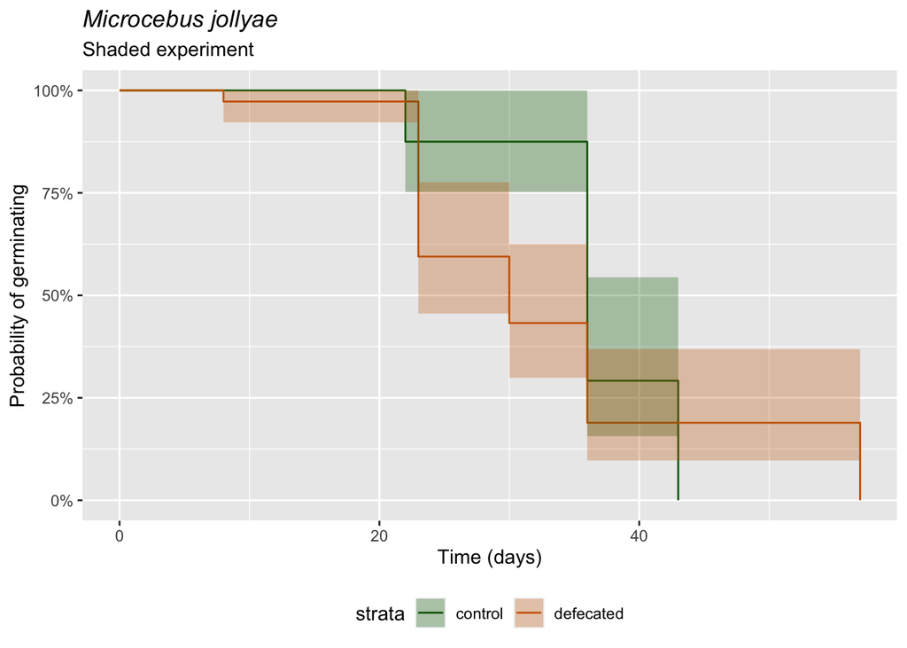

```r
jollyae_closed_yes_km_plot <- autoplot(jollyae_closed_yes_km_fit)
jollyae_closed_yes_km_plot + labs(title = "Microcebus jollyae",subtitle = "Shaded experiment",
                                y = "Probability of germinating", x = "Time (days)") +
  theme(plot.title = element_text(face = "italic")) +
  scale_color_manual(values=c("darkgreen", "darkorange3")) +
  scale_fill_manual(values=c("darkgreen", "darkorange3")) +
  geom_text(x=75, y=.2, label="p = .7") + theme(legend.position="bottom")
```

One problem though is that this graph is upside down. I used scale_y_reverse() to reverse the scale, but now the numbers are wrong and the annotated p value is gone.

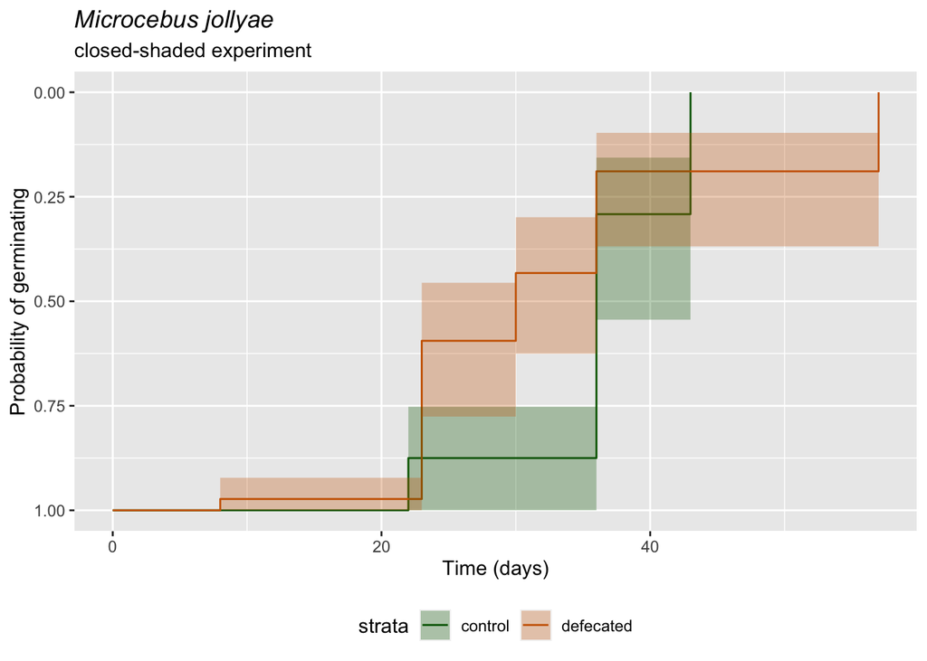

```r
jollyae_closed_yes_km_plot + labs(title = "Microcebus jollyae",subtitle = "closed-shaded experiment",
                                y = "Probability of germinating", x = "Time (days)") +
  theme(plot.title = element_text(face = "italic")) +
  scale_color_manual(values=c("darkgreen", "darkorange3")) +
  scale_fill_manual(values=c("darkgreen", "darkorange3")) +
  geom_text(x=75, y=.75, label="p = .7") + theme(legend.position="bottom") + scale_y_reverse()
```

This is the original graph

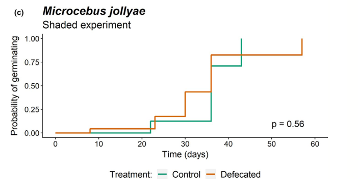

*Microcebus jollyae* survival graph for the shaded plot experiment

This the the Cox test with fragility. The summary includes the Chi square value, the degrees of freedom and the p-value.

```r
jollyae_closed_yes_cox <- coxph(Surv(germ_time, status) ~ treatment, data=jollyae_closed_yes)
summary(jollyae_closed_yes_cox)
```

```
## Call:
## coxph(formula = Surv(germ_time, status) ~ treatment, data = jollyae_closed_yes)
##
##   n= 61, number of events= 61
##
##                      coef exp(coef) se(coef)     z Pr(>|z|)
## treatmentdefecated 0.1144    1.1212   0.2785 0.411    0.681
##
##                    exp(coef) exp(-coef) lower .95 upper .95
## treatmentdefecated     1.121     0.8919    0.6496     1.935
##
## Concordance= 0.588  (se = 0.047 )
## Likelihood ratio test= 0.17  on 1 df,   p=0.7
## Wald test            = 0.17  on 1 df,   p=0.7
## Score (logrank) test = 0.17  on 1 df,   p=0.7
```

These are the statistics needed for the table

X^2 = 0.17

df = 1

p = .7

### Survival analysis table

Now, I will construct a table with the replication values alongside the original values

Legend for table construction object:

Species: r = *Microcebus rufus*, j = *Microcebus jollyae*

Experiment: p = Petri dish, f = Forest ground, s = semi-shaded plot, c = shaded plot

Study: rep = replication, og = original

Model: n = Number of observations l = Seedling length, t = Germination time, r = germination rate, sur = survival analysis

```r
r_p_rep_sur <- c("X^2 = 41.38", "df = 1", "p = 1e-10")
r_p_og_sur <- c("X^2 = 20.62", "df = 1", "p < .0001")

r_f_rep_sur <- c("X^2 = NA", "df = NA", "p = NA")
r_f_og_sur <- c("X^2 = NA", "df = NA", "p = NA")

j_p_rep_sur <- c("X^2 = 0.02", "df = 1","p = 0.9")
j_p_og_sur <- c("X^2 = 66.08", "df = 1", "p = .96")

j_s_rep_sur <- c("X^2 = 1.4", "df = 1", "p = 0.2")
j_s_og_sur <- c("X^2 = 1.60", "df = 1", "p = .20")

j_c_rep_sur <- c("X^2 = 0.17", "df = 1", "p = .7")
j_c_og_sur <- c("X2 = 0.30", "df = 1", "p = .56")

t1_sur <- cbind(r_p_rep_sur, r_p_og_sur, r_f_rep_sur, r_f_og_sur, j_p_rep_sur, j_p_og_sur,
                j_s_rep_sur, j_s_og_sur, j_c_rep_sur, j_c_og_sur)
t2_sur <- as.data.frame(t1_sur)
t3_sur <- t2_sur %>% gt() %>%
  cols_label(r_p_rep_sur = "Petri dish experiment replication values",
             r_p_og_sur = "Petri dish experiment original values",
             r_f_rep_sur = "Forest ground experiment replication values",
             r_f_og_sur = "Forest ground experiment original values",
             j_p_rep_sur = "Petri dish experiment replication values",
             j_p_og_sur = "Petri dish experiment original values",
             j_s_rep_sur = "Semi-shaded plot experiment replication values",
             j_s_og_sur = "Semi-shaded plot experiment original values",
             j_c_rep_sur = "Shaded plot experiment replication values",
             j_c_og_sur = "Shaded plot experiment original values") %>%
  tab_header(title = md("Summary table of the Cox model with frailty")) %>%
  tab_spanner(label = "Microcebus rufus", columns = c(r_p_rep_sur, r_p_og_sur, r_f_rep_sur, r_f_og_sur)) %>%
  tab_spanner(label = "Microcebus Jollyae", columns = c(j_p_rep_sur, j_p_og_sur,
                                            j_s_rep_sur, j_s_og_sur, j_c_rep_sur, j_c_og_sur))
t3_sur
```

Summary table of the Cox model with frailty

| Microcebus rufus Petri dish experiment replication values | Microcebus rufus Petri dish experiment original values | Microcebus rufus Forest ground experiment replication values | Microcebus rufus Forest ground experiment original values | Microcebus Jollyae Petri dish experiment replication values | Microcebus Jollyae Petri dish experiment original values | Microcebus Jollyae Semi-shaded plot experiment replication values | Microcebus Jollyae Semi-shaded plot experiment original values | Microcebus Jollyae Shaded plot experiment replication values | Microcebus Jollyae Shaded plot experiment original values |
| --- | --- | --- | --- | --- | --- | --- | --- | --- | --- |
| X^2 = 41.38 | X^2 = 20.62 | X^2 = NA | X^2 = NA | X^2 = 0.02 | X^2 = 66.08 | X^2 = 1.4 | X^2 = 1.60 | X^2 = 0.17 | X2 = 0.30 |
| df = 1 | df = 1 | df = NA | df = NA | df = 1 | df = 1 | df = 1 | df = 1 | df = 1 | df = 1 |
| p = 1e-10 | p < .0001 | p = NA | p = NA | p = 0.9 | p = .96 | p = 0.2 | p = .20 | p = .7 | p = .56 |

This is the original table.

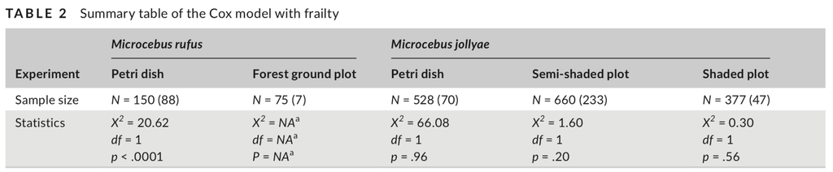